# 1. Análise inicial

Jonas Coelho

07/05/2021

# I. Abrindo dados do censo 2020

Vamos iniciar com os microdados do censo que podem ser obtidos nesse endereço: https://www.gov.br/inep/pt-br/acesso-a-informacao/dados-abertos/microdados/censo-escolar . Note que o arquivo possui 2GB e pode levar horas para ser baixado mesmo em boa conexão.

Primeiramente, vamos importar os dicionários disponíveis na pasta de anexos:

```r
dici_escolas <- readxl::read_excel('../dados/dicionario.xlsx', sheet = 'BAS_ESCOLA', skip = 7) %>%
  janitor::clean_names() %>%
  slice(3:n())
```

Agora visualizar:

```r
dici_escolas %>%
    knitr::kable("html") %>%
    kable_styling() %>%
    scroll_box(width = "100%", height = "500px")
```

n

nome_da_variavel

descricao_da_variavel

tipo

tam_1

categoria_2

coleta_por_ano_s_sim_nao

x8

x9

x10

x11

x12

x13

x14

x15

x16

x17

x18

x19

x20

notas_sobre_diferencas_entre_os_anos

1

NU_ANO_CENSO

Ano do Censo

Num

4

NA

s

s

s

s

s

s

s

s

s

s

s

s

s

s

NA

DADOS DA ESCOLA

NA

NA

NA

NA

NA

NA

NA

NA

NA

NA

NA

NA

NA

NA

NA

NA

NA

NA

NA

NA

2

CO_ENTIDADE

Código da Escola

Num

8

NA

s

s

s

s

s

s

s

s

s

s

s

s

s

s

NA

3

NO_ENTIDADE

Nome da Escola

Char

100

NA

s

s

s

s

s

s

s

s

s

s

s

s

s

s

NA

4

CO_ORGAO_REGIONAL

Código do Órgão Regional de Ensino

Char

5

NA

s

s

s

s

s

s

s

s

s

s

s

s

s

s

NA

5

TP_SITUACAO_FUNCIONAMENTO

Situação de funcionamento

Num

1

1 - Em Atividade 2 - Paralisada 3 - Extinta (ano do Censo) 4 - Extinta em Anos Anteriores

s

s

s

s

s

s

s

s

s

s

s

s

s

s

NA

6

DT_ANO_LETIVO_INICIO

Início do ano letivo

Data

NA

NA

s

s

s

s

s

s

s

s

s

s

s

s

s

NA

7

DT_ANO_LETIVO_TERMINO

Término (Previsão) do ano letivo

Data

NA

NA

s

s

s

s

s

s

s

s

s

s

s

s

s

NA

8

CO_REGIAO

Código da região geográfica

Num

1

NA

s

s

s

s

s

s

s

s

s

s

s

s

s

s

NA

9

CO_MESORREGIAO

Código da mesorregião

Num

4

NA

s

s

s

s

s

s

s

s

s

s

s

s

s

s

NA

10

CO_MICRORREGIAO

Código da microrregião

Num

5

NA

s

s

s

s

s

s

s

s

s

s

s

s

s

s

NA

11

CO_UF

Código da UF

Num

2

NA

s

s

s

s

s

s

s

s

s

s

s

s

s

s

NA

12

CO_MUNICIPIO

Código do Município

Num

7

NA

s

s

s

s

s

s

s

s

s

s

s

s

s

s

NA

13

CO_DISTRITO

Código completo do Distrito da escola

Num

9

NA

s

s

s

s

s

s

s

s

s

s

s

s

s

s

NA

14

TP_DEPENDENCIA

Dependência Administrativa

Num

1

1 - Federal 2 - Estadual 3 - Municipal 4 - Privada

s

s

s

s

s

s

s

s

s

s

s

s

s

s

NA

15

TP_LOCALIZACAO

Localização

Num

1

1 - Urbana 2 - Rural

s

s

s

s

s

s

s

s

s

s

s

s

s

s

NA

16

TP_LOCALIZACAO_DIFERENCIADA

Localização diferenciada da escola

Num

1

0 - A escola não está em área de localização diferenciada 1 - Área de assentamento 2 - Terra indígena 3 - Área onde se localiza comunidade remanescente de quilombos

s

s

s

s

s

s

s

s

s

s

s

s

s

s

De 2007 a 2011:  
0 - Não se aplica 1 - Área de assentamento 2 - Terra indígena 3 - Área remanescente de quilombos De 2012 a 2018:  
0 - A escola não está em área de localização diferenciada 1 - Área de assentamento 2 - Terra indígena 3 - Área remanescente de quilombos 4 - Unidade de uso sustentável 5 - Unidade de uso sustentável em terra indígena 6 - Unidade de uso sustentável em área remanescente de quilombos

17

IN_VINCULO_SECRETARIA_EDUCACAO

Órgão que a escola pública está vinculada - Secretaria de Educação/Ministério da Educação

Num

1

0 - Não 1 - Sim

Não aplicável para escolas privadas

s

s

NA

18

IN_VINCULO_SEGURANCA_PUBLICA

Órgão que a escola pública está vinculada - Secretaria de Segurança Pública/Forças Armadas/Militar

Num

1

0 - Não 1 - Sim

Não aplicável para escolas privadas

s

s

NA

19

IN_VINCULO_SECRETARIA_SAUDE

Órgão que a escola pública está vinculada - Secretaria de Saúde/Ministério da Saúde

Num

1

0 - Não 1 - Sim

Não aplicável para escolas privadas

s

s

NA

20

IN_VINCULO_OUTRO_ORGAO

Órgão que a escola pública está vinculada - Outro órgão da administração pública

Num

1

0 - Não 1 - Sim

Não aplicável para escolas privadas

s

s

NA

21

TP_CATEGORIA_ESCOLA_PRIVADA

Categoria da escola privada

Num

1

1 - Particular 2 - Comunitária 3 - Confessional 4 - Filantrópica

Não aplicável para escolas públicas

s

s

s

s

s

s

s

s

s

s

s

s

s

s

NA

22

IN_CONVENIADA_PP

Conveniada com o poder público

Num

1

0 - Não 1 - Sim

Não aplicável para escolas públicas

s

s

s

s

s

s

s

s

s

s

s

s

s

s

NA

23

TP_CONVENIO_PODER_PUBLICO

Dependência do convênio com o poder público

Num

1

1 - Municipal 2 - Estadual 3 - Estadual e Municipal

Não aplicável para escolas públicas ou privadas não conveniadas

s

s

s

s

s

s

s

s

s

s

s

s

s

NA

24

IN_MANT_ESCOLA_PRIVADA_EMP

Mantenedora da escola privada - Empresa ou grupo empresarial do setor privado ou pessoa física

Num

1

0 - Não 1 - Sim

Não aplicável para escolas públicas

s

s

s

s

s

s

s

s

s

s

s

s

s

s

NA

25

IN_MANT_ESCOLA_PRIVADA_ONG

Mantenedora da escola privada - Organização não governamental (ONG) - internacional ou nacional.

Num

1

0 - Não 1 - Sim

Não aplicável para escolas públicas

s

s

NA

26

IN_MANT_ESCOLA_PRIVADA_OSCIP

Mantenedora da escola privada - Organização da Sociedade Civil de Interesse Público (Oscip)

Num

1

0 - Não 1 - Sim

Não aplicável para escolas públicas

s

s

NA

27

IN_MANT_ESCOLA_PRIV_ONG_OSCIP

Mantenedora da escola privada - Organização não governamental (ONG) - internacional ou nacional. Organização da Sociedade Civil de Interesse Público (Oscip)

Num

1

0 - Não 1 - Sim

Não aplicável para escolas públicas

s

s

s

s

s

s

s

s

s

s

s

s

s

s

A partir de 2019: Variável derivada juntando IN_MANT_ESCOLA_PRIVADA_ONG e IN_MANT_ESCOLA_PRIVADA_OSCIP

28

IN_MANT_ESCOLA_PRIVADA_SIND

Mantenedora da escola privada - Sindicatos de trabalhadores ou patronais, associações e cooperativas

Num

1

0 - Não 1 - Sim

Não aplicável para escolas públicas

s

s

s

s

s

s

s

s

s

s

s

s

s

s

NA

29

IN_MANT_ESCOLA_PRIVADA_SIST_S

Mantenedora da escola privada - Sistema S (Sesi, Senai, Sesc, Outros)

Num

1

0 - Não 1 - Sim

Não aplicável para escolas públicas

s

s

s

s

s

s

s

s

s

NA

30

IN_MANT_ESCOLA_PRIVADA_S_FINS

Mantenedora da escola privada - Instituições sem fins lucrativos

Num

1

0 - Não 1 - Sim

Não aplicável para escolas públicas

s

s

s

s

s

s

s

s

s

s

s

s

NA

31

NU_CNPJ_ESCOLA_PRIVADA

Número do CNPJ da escola privada

Char

14

99999999999999 - Sem declaração - Não aplicável para escolas públicas

s

s

s

s

s

s

s

s

s

s

s

s

s

s

NA

32

NU_CNPJ_MANTENEDORA

Número do CNPJ da mantenedora principal da escola privada

Char

14

99999999999999 - Sem declaração - Não aplicável para escolas públicas

s

s

s

s

s

s

s

s

s

s

s

NA

33

TP_REGULAMENTACAO

Regulamentação/Autorização no conselho ou órgão municipal, estadual ou federal de educação

Num

1

0 - Não 1 - Sim 2 - Em tramitação

s

s

s

s

s

s

s

s

s

s

s

s

s

s

NA

34

TP_RESPONSAVEL_REGULAMENTACAO

Esfera administrativa do conselho ou órgão responsável pela Regulamentação/Autorização

Num

1

1 - Federal 2 - Estadual 3 - Municipal 4 - Estadual e Municipal 5 - Federal e Estadual 6 - Federal, Estadual e Municipal 9 - Não informado

Não aplicável para escolas sem regulamentação

s

s

NA

35

CO_ESCOLA_SEDE_VINCULADA

Código da escola sede

Num

8

- Não aplicável para escolas que não possuem vínculo

s

s

s

s

s

s

NA

36

CO_IES_OFERTANTE

Código da IES vinculada à escola

Num

14

- Não aplicável para escolas que não possuem vínculo

s

s

s

s

s

s

NA

37

IN_LOCAL_FUNC_PREDIO_ESCOLAR

Local de funcionamento da escola - Prédio Escolar

Num

1

0 - Não 1 - Sim

s

s

s

s

s

s

s

s

s

s

s

s

s

s

NA

38

TP_OCUPACAO_PREDIO_ESCOLAR

Forma de ocupação do Prédio escolar

Num

1

1 - Próprio 2 - Alugado 3 - Cedido

Não aplicável para escolas que não ocupam prédio escolar

s

s

s

s

s

s

s

s

s

s

NA

39

IN_LOCAL_FUNC_SOCIOEDUCATIVO

Local de funcionamento da escola - Unidade de Atendimento socioeducativo

Num

1

0 - Não 1 - Sim

s

s

s

s

s

s

s

s

NA

40

IN_LOCAL_FUNC_UNID_PRISIONAL

Local de funcionamento da escola - Unidade Prisional

Num

1

0 - Não 1 - Sim

s

s

s

s

s

s

s

s

NA

41

IN_LOCAL_FUNC_PRISIONAL_SOCIO

Local de funcionamento da escola - Unidade Prisional ou Unidade de atendimento socioeducativo

Num

1

0 - Não 1 - Sim

s

s

s

s

s

s

s

s

s

s

s

s

s

s

NA

42

IN_LOCAL_FUNC_GALPAO

Local de funcionamento da escola - Galpão/Rancho/Paiol/Barracão

Num

1

0 - Não 1 - Sim

s

s

s

s

s

s

s

s

s

s

s

s

s

s

NA

43

TP_OCUPACAO_GALPAO

Forma de ocupação do Galpão/Rancho/Paiol/Barracão

Num

1

1 - Próprio 2 - Alugado 3 - Cedido 9 - Não informado

Não aplicável para escolas que não ocupam Galpão/Rancho/Paiol/Barracão

s

s

s

s

s

s

s

s

s

s

NA

44

IN_LOCAL_FUNC_SALAS_OUTRA_ESC

Local de funcionamento da escola - Salas em outra escola

Num

1

0 - Não 1 - Sim

s

s

s

s

s

s

s

s

s

s

s

s

s

s

NA

45

IN_LOCAL_FUNC_OUTROS

Local de funcionamento da escola - Outros

Num

1

0 - Não 1 - Sim

s

s

s

s

s

s

s

s

s

s

s

s

s

s

NA

46

IN_PREDIO_COMPARTILHADO

Prédio compartilhado com outra escola

Num

1

0 - Não 1 - Sim

Não aplicável para escolas que não ocupam prédio escolar

s

s

s

s

s

s

s

s

s

s

s

s

s

s

NA

47

IN_AGUA_POTAVEL

Fornece água potável para o consumo humano

Num

1

0 - Não 1 - Sim

s

s

NA

48

IN_AGUA_REDE_PUBLICA

Abastecimento de água - Rede pública

Num

1

0 - Não 1 - Sim

s

s

s

s

s

s

s

s

s

s

s

s

s

s

NA

49

IN_AGUA_POCO_ARTESIANO

Abastecimento de água - Poço artesiano

Num

1

0 - Não 1 - Sim

s

s

s

s

s

s

s

s

s

s

s

s

s

s

NA

50

IN_AGUA_CACIMBA

Abastecimento de água - Cacimba/Cisterna/Poço

Num

1

0 - Não 1 - Sim

s

s

s

s

s

s

s

s

s

s

s

s

s

s

NA

51

IN_AGUA_FONTE_RIO

Abastecimento de água - Fonte/Rio/Igarapé/Riacho/Córrego

Num

1

0 - Não 1 - Sim

s

s

s

s

s

s

s

s

s

s

s

s

s

s

NA

52

IN_AGUA_INEXISTENTE

Abastecimento de água - Não há abastecimento de água

Num

1

0 - Não 1 - Sim

s

s

s

s

s

s

s

s

s

s

s

s

s

s

NA

53

IN_ENERGIA_REDE_PUBLICA

Abastecimento de energia elétrica - Rede pública

Num

1

0 - Não 1 - Sim

s

s

s

s

s

s

s

s

s

s

s

s

s

s

NA

54

IN_ENERGIA_GERADOR_FOSSIL

Abastecimento de energia elétrica - Gerador movido a combustível fóssil

Num

1

0 - Não 1 - Sim

s

s

NA

55

IN_ENERGIA_RENOVAVEL

Abastecimento de energia elétrica - Fontes de energia renováveis ou alternativas (gerador a biocombustível e/ou biodigestores, eólica, solar, outras)

Num

1

0 - Não 1 - Sim

s

s

NA

56

IN_ENERGIA_INEXISTENTE

Abastecimento de energia elétrica - Não há energia elétrica

Num

1

0 - Não 1 - Sim

s

s

s

s

s

s

s

s

s

s

s

s

s

s

NA

57

IN_ESGOTO_REDE_PUBLICA

Esgoto sanitário - Rede pública

Num

1

0 - Não 1 - Sim

s

s

s

s

s

s

s

s

s

s

s

s

s

s

NA

58

IN_ESGOTO_FOSSA_SEPTICA

Esgoto sanitário - Fossa Séptica

Num

1

0 - Não 1 - Sim

s

s

NA

59

IN_ESGOTO_FOSSA_COMUM

Esgoto sanitário - Fossa rudimentar/comum

Num

1

0 - Não 1 - Sim

s

s

NA

60

IN_ESGOTO_FOSSA

Esgoto sanitário - Fossa

Num

1

0 - Não 1 - Sim

s

s

s

s

s

s

s

s

s

s

s

s

s

s

A partir de 2019: Variável derivada juntando IN_ESGOTO_FOSSA_SEPTICA e IN_ESGOTO_FOSSA_COMUM

61

IN_ESGOTO_INEXISTENTE

Esgoto sanitário - Não há esgotamento sanitário

Num

1

0 - Não 1 - Sim

s

s

s

s

s

s

s

s

s

s

s

s

s

s

NA

62

IN_LIXO_SERVICO_COLETA

Destinação do lixo - Serviço de coleta

Num

1

0 - Não 1 - Sim

s

s

s

s

s

s

s

s

s

s

s

s

s

s

NA

63

IN_LIXO_QUEIMA

Destinação do lixo - Queima

Num

1

0 - Não 1 - Sim

s

s

s

s

s

s

s

s

s

s

s

s

s

s

NA

64

IN_LIXO_ENTERRA

Destinação do lixo - Enterra

Num

1

0 - Não 1 - Sim

s

s

s

s

s

s

s

s

s

s

s

s

s

s

NA

65

IN_LIXO_DESTINO_FINAL_PUBLICO

Destinação do lixo - Leva a uma destinação final financiada pelo poder público

Num

1

0 - Não 1 - Sim

s

s

NA

66

IN_LIXO_DESCARTA_OUTRA_AREA

Destinação do lixo - Descarta em outra área

Num

1

0 - Não 1 - Sim

s

s

NA

67

IN_TRATAMENTO_LIXO_SEPARACAO

Tratamento do lixo/resíduos que a escola realiza - Separação do lixo/resíduos

Num

1

0 - Não 1 - Sim 9 - Não informado

s

s

NA

68

IN_TRATAMENTO_LIXO_REUTILIZA

Tratamento do lixo/resíduos que a escola realiza - Reaproveitamento/reutilização

Num

1

0 - Não 1 - Sim 9 - Não informado

s

s

NA

69

IN_TRATAMENTO_LIXO_RECICLAGEM

Tratamento do lixo/resíduos que a escola realiza - Reciclagem

Num

1

0 - Não 1 - Sim 9 - Não informado

s

s

NA

70

IN_TRATAMENTO_LIXO_INEXISTENTE

Tratamento do lixo/resíduos que a escola realiza - Não faz tratamento

Num

1

0 - Não 1 - Sim 9 - Não informado

s

s

NA

71

IN_ALMOXARIFADO

Dependências físicas existentes e utilizadas na escola - Almoxarifado

Num

1

0 - Não 1 - Sim

s

s

s

s

s

s

s

s

s

NA

72

IN_AREA_VERDE

Dependências físicas existentes e utilizadas na escola - Área Verde

Num

1

0 - Não 1 - Sim

s

s

s

s

s

s

s

s

s

NA

73

IN_AUDITORIO

Dependências físicas existentes e utilizadas na escola - Auditório

Num

1

0 - Não 1 - Sim

s

s

s

s

s

s

s

s

s

NA

74

IN_BANHEIRO

Dependências físicas existentes e utilizadas na escola - Banheiro

Num

1

0 - Não 1 - Sim

s

s

NA

75

IN_BANHEIRO_EI

Dependências físicas existentes e utilizadas na escola - Banheiro adequado à educação infantil

Num

1

0 - Não 1 - Sim

s

s

s

s

s

s

s

s

s

s

s

s

NA

76

IN_BANHEIRO_PNE

Dependências físicas existentes e utilizadas na escola - Banheiro acessível, adequado ao uso de pessoas com deficiência ou mobilidade reduzida

Num

1

0 - Não 1 - Sim

s

s

s

s

s

s

s

s

s

s

s

s

s

s

NA

77

IN_BANHEIRO_FUNCIONARIOS

Dependências físicas existentes e utilizadas na escola - Banheiro exclusivo para os funcionários

Num

1

0 - Não 1 - Sim

s

s

NA

78

IN_BANHEIRO_CHUVEIRO

Dependências físicas existentes e utilizadas na escola - Banheiro ou vestiário com chuveiro

Num

1

0 - Não 1 - Sim

s

s

s

s

s

s

s

s

s

De 2012 a 2018: “Banheiro com chuveiro” A partir de 2019: “Banheiro ou vestiário com chuveiro”

79

IN_BIBLIOTECA

Dependências físicas existentes e utilizadas na escola - Biblioteca

Num

1

0 - Não 1 - Sim

s

s

s

s

s

s

s

s

s

s

s

s

NA

80

IN_BIBLIOTECA_SALA_LEITURA

Dependências físicas existentes e utilizadas na escola - Biblioteca e/ou Sala de leitura

Num

1

0 - Não 1 - Sim

s

s

s

s

s

s

s

s

s

s

s

s

s

s

NA

81

IN_COZINHA

Dependências físicas existentes e utilizadas na escola - Cozinha

Num

1

0 - Não 1 - Sim

s

s

s

s

s

s

s

s

s

s

s

s

s

s

NA

82

IN_DESPENSA

Dependências físicas existentes e utilizadas na escola - Despensa

Num

1

0 - Não 1 - Sim

s

s

s

s

s

s

s

s

s

NA

83

IN_DORMITORIO_ALUNO

Dependências físicas existentes e utilizadas na escola - Dormitório de Aluno (a)

Num

1

0 - Não 1 - Sim

s

s

s

s

s

s

s

s

s

De 2012 a 2018: “Alojamento de aluno” A partir de 2019: "Dormitório de aluno(a)

84

IN_DORMITORIO_PROFESSOR

Dependências físicas existentes e utilizadas na escola - Dormitório de professor (a)

Num

1

0 - Não 1 - Sim

s

s

s

s

s

s

s

s

s

De 2012 a 2018: “Alojamento de professor” A partir de 2019: “Dormitório de professor(a)”

85

IN_LABORATORIO_CIENCIAS

Dependências físicas existentes e utilizadas na escola - Laboratório de ciências

Num

1

0 - Não 1 - Sim

s

s

s

s

s

s

s

s

s

s

s

s

s

s

NA

86

IN_LABORATORIO_INFORMATICA

Dependências físicas existentes e utilizadas na escola - Laboratório de informática

Num

1

0 - Não 1 - Sim

s

s

s

s

s

s

s

s

s

s

s

s

s

s

NA

87

IN_PATIO_COBERTO

Dependências físicas existentes e utilizadas na escola - Pátio Coberto

Num

1

0 - Não 1 - Sim

s

s

s

s

s

s

s

s

s

NA

88

IN_PATIO_DESCOBERTO

Dependências físicas existentes e utilizadas na escola - Pátio Descoberto

Num

1

0 - Não 1 - Sim

s

s

s

s

s

s

s

s

s

NA

89

IN_PARQUE_INFANTIL

Dependências físicas existentes e utilizadas na escola - Parque infantil

Num

1

0 - Não 1 - Sim

s

s

s

s

s

s

s

s

s

s

s

s

s

s

NA

90

IN_PISCINA

Dependências físicas existentes e utilizadas na escola - Piscina

Num

1

0 - Não 1 - Sim

s

s

NA

91

IN_QUADRA_ESPORTES

Dependências físicas existentes e utilizadas na escola - Quadra de esportes coberta ou descoberta

Num

1

0 - Não 1 - Sim

s

s

s

s

s

s

s

s

s

s

s

s

s

s

NA

92

IN_QUADRA_ESPORTES_COBERTA

Dependências físicas existentes e utilizadas na escola - Quadra de esportes Coberta

Num

1

0 - Não 1 - Sim

s

s

s

s

s

s

s

s

s

s

NA

93

IN_QUADRA_ESPORTES_DESCOBERTA

Dependências físicas existentes e utilizadas na escola - Quadra de esportes Descoberta

Num

1

0 - Não 1 - Sim

s

s

s

s

s

s

s

s

s

s

NA

94

IN_REFEITORIO

Dependências físicas existentes e utilizadas na escola - Refeitório

Num

1

0 - Não 1 - Sim

s

s

s

s

s

s

s

s

s

NA

95

IN_SALA_ATELIE_ARTES

Dependências físicas existentes e utilizadas na escola - Sala/ateliê de artes

Num

1

0 - Não 1 - Sim

s

s

NA

96

IN_SALA_MUSICA_CORAL

Dependências físicas existentes e utilizadas na escola - Sala de música/coral

Num

1

0 - Não 1 - Sim

s

s

NA

97

IN_SALA_ESTUDIO_DANCA

Dependências físicas existentes e utilizadas na escola - Sala/estúdio de dança

Num

1

0 - Não 1 - Sim

s

s

NA

98

IN_SALA_MULTIUSO

Dependências físicas existentes e utilizadas na escola - Sala multiuso (música, dança e artes)

Num

1

0 - Não 1 - Sim

s

s

NA

99

IN_SALA_DIRETORIA

Dependências físicas existentes e utilizadas na escola - Sala de Diretoria

Num

1

0 - Não 1 - Sim

s

s

s

s

s

s

s

s

s

s

s

s

s

s

NA

100

IN_SALA_LEITURA

Dependências físicas existentes e utilizadas na escola - Sala de Leitura

Num

1

0 - Não 1 - Sim

s

s

s

s

s

s

s

s

s

s

s

s

NA

101

IN_SALA_PROFESSOR

Dependências físicas existentes e utilizadas na escola - Sala de professores

Num

1

0 - Não 1 - Sim

s

s

s

s

s

s

s

s

s

s

s

s

s

s

NA

102

IN_SALA_REPOUSO_ALUNO

Dependências físicas existentes e utilizadas na escola - Sala de repouso para aluno(a)

Num

1

0 - Não 1 - Sim

s

s

NA

103

IN_SECRETARIA

Dependências físicas existentes e utilizadas na escola - Sala de secretaria

Num

1

0 - Não 1 - Sim

s

s

s

s

s

s

s

s

s

NA

104

IN_SALA_ATENDIMENTO_ESPECIAL

Dependências físicas existentes e utilizadas na escola - Sala de recursos Multifuncionais para Atendimento Educacional Especializado (AEE)

Num

1

0 - Não 1 - Sim

s

s

s

s

s

s

s

s

s

s

s

s

s

s

NA

105

IN_TERREIRAO

Dependências físicas existentes e utilizadas na escola - Terreirão (área para prática desportiva e recreação sem cobertura, sem piso e sem edificações)

Num

1

0 - Não 1 - Sim

s

s

NA

106

IN_VIVEIRO

Dependências físicas existentes e utilizadas na escola - Viveiro/criação de animais

Num

1

0 - Não 1 - Sim

s

s

NA

107

IN_DEPENDENCIAS_OUTRAS

Dependências existentes na escola - Nenhuma das dependência relacionadas

Num

1

0 - Não 1 - Sim

s

s

s

s

s

s

s

s

s

s

s

s

s

s

NA

108

IN_ACESSIBILIDADE_CORRIMAO

Recursos de acessibilidade para pessoas com deficiência ou mobilidade reduzida nas vias de circulação interna na escola - Corrimão e guarda corpos

Num

1

0 - Não 1 - Sim

s

s

NA

109

IN_ACESSIBILIDADE_ELEVADOR

Recursos de acessibilidade para pessoas com deficiência ou mobilidade reduzida nas vias de circulação interna na escola - Elevador

Num

1

0 - Não 1 - Sim

s

s

NA

110

IN_ACESSIBILIDADE_PISOS_TATEIS

Recursos de acessibilidade para pessoas com deficiência ou mobilidade reduzida nas vias de circulação interna na escola - Pisos táteis

Num

1

0 - Não 1 - Sim

s

s

NA

111

IN_ACESSIBILIDADE_VAO_LIVRE

Recursos de acessibilidade para pessoas com deficiência ou mobilidade reduzida nas vias de circulação interna na escola - Portas com vão livre de no mínimo 80 cm

Num

1

0 - Não 1 - Sim

s

s

NA

112

IN_ACESSIBILIDADE_RAMPAS

Recursos de acessibilidade para pessoas com deficiência ou mobilidade reduzida nas vias de circulação interna na escola - Rampas

Num

1

0 - Não 1 - Sim

s

s

NA

113

IN_ACESSIBILIDADE_SINAL_SONORO

Recursos de acessibilidade para pessoas com deficiência ou mobilidade reduzida nas vias de circulação interna na escola - Sinalização sonora

Num

1

0 - Não 1 - Sim

s

s

NA

114

IN_ACESSIBILIDADE_SINAL_TATIL

Recursos de acessibilidade para pessoas com deficiência ou mobilidade reduzida nas vias de circulação interna na escola - Sinalização tátil (piso/paredes)

Num

1

0 - Não 1 - Sim

s

s

NA

115

IN_ACESSIBILIDADE_SINAL_VISUAL

Recursos de acessibilidade para pessoas com deficiência ou mobilidade reduzida nas vias de circulação interna na escola - Sinalização visual (piso/paredes)

Num

1

0 - Não 1 - Sim

s

s

NA

116

IN_ACESSIBILIDADE_INEXISTENTE

Recursos de acessibilidade para pessoas com deficiência ou mobilidade reduzida nas vias de circulação interna na escola - Nenhum dos recursos de acessibilidade listado

Num

1

0 - Não 1 - Sim

s

s

NA

117

QT_SALAS_UTILIZADAS_DENTRO

Número de salas de aula utilizadas na escola - Dentro do prédio

Num

4

NA

s

s

NA

118

QT_SALAS_UTILIZADAS_FORA

Número de salas de aula utilizadas na escola - Fora do prédio

Num

4

NA

s

s

NA

119

QT_SALAS_UTILIZADAS

Número de salas de aula utilizadas na escola (dentro e fora do prédio)

Num

4

NA

s

s

s

s

s

s

s

s

s

s

s

s

s

s

A partir de 2019: Variável derivada juntando QT_SALAS_UTILIZADAS_DENTRO e QT_SALAS_UTILIZADAS_FORA

120

QT_SALAS_UTILIZA_CLIMATIZADAS

Condições das salas de aula utilizadas na escola (dentro e fora do prédio escolar) - Número de salas de aula climatizadas

Num

4

NA

s

s

NA

121

QT_SALAS_UTILIZADAS_ACESSIVEIS

Condições das salas de aula utilizadas na escola (dentro e fora do prédio escolar) - Número de salas de aula com acessibilidade para pessoas com deficiência ou mobilidade reduzida.

Num

4

NA

s

s

NA

122

IN_EQUIP_PARABOLICA

Equipamentos existentes na escola para uso técnico e administrativo - Antena parabólica

Num

1

0 - Não 1 - Sim

s

s

s

s

s

s

s

s

s

s

s

s

s

s

NA

123

IN_COMPUTADOR

Equipamentos existentes na escola para uso técnico e administrativo - Computador

Num

1

0 - Não 1 - Sim

s

s

s

s

s

s

s

s

s

s

s

s

s

s

NA

124

IN_EQUIP_COPIADORA

Equipamentos existentes na escola para uso técnico e administrativo - Copiadora

Num

1

0 - Não 1 - Sim

s

s

s

s

s

s

s

s

s

s

s

s

s

s

NA

125

IN_EQUIP_IMPRESSORA

Equipamentos existentes na escola para uso técnico e administrativo - Impressora

Num

1

0 - Não 1 - Sim

s

s

s

s

s

s

s

s

s

s

s

s

s

s

NA

126

IN_EQUIP_IMPRESSORA_MULT

Equipamentos existentes na escola para uso técnico e administrativo - Impressora Multifuncional

Num

1

0 - Não 1 - Sim

s

s

s

s

s

s

NA

127

IN_EQUIP_SCANNER

Equipamentos existentes na escola para uso técnico e administrativo - Scanner

Num

1

0 - Não 1 - Sim

s

s

NA

128

IN_EQUIP_NENHUM

Nenhum dos equipamentos listados para uso técnico e administrativo - Antena parabólica, Computador, Copiadora, Impressora, Impressora Multifuncional ou Scanner

Num

1

0 - Não 1 - Sim

s

NA

129

IN_EQUIP_DVD

Equipamentos existentes na escola para o processo ensino aprendizagem - DVD/Blu-ray

Num

1

0 - Não 1 - Sim

s

s

s

s

s

s

s

s

s

s

s

s

s

s

NA

130

QT_EQUIP_DVD

Quantidade de Aparelhos de DVD/Blue-ray

Num

5

88888 - registro com marcação de valor extremo (valor superior ao limite máximo de 4 equipamentos para cada 3 salas existentes - foram marcados apenas valores>3)

s

s

s

s

s

s

s

s

Em 2019: primeiro ano em que foi aplicado tratamento de valores extremos, que são marcados com o código 88888.

131

IN_EQUIP_SOM

Equipamentos existentes na escola para o processo ensino aprendizagem - Aparelho de som

Num

1

0 - Não 1 - Sim

s

s

s

s

s

s

s

s

s

NA

132

QT_EQUIP_SOM

Quantidade de Aparelhos de som

Num

5

88888 - registro com marcação de valor extremo (valor superior ao limite máximo de 4 equipamentos para cada 3 salas existentes - foram marcados apenas valores>3)

s

s

s

s

s

s

s

s

Em 2019: primeiro ano em que foi aplicado tratamento de valores extremos, que são marcados com o código 88888.

133

IN_EQUIP_TV

Equipamentos existentes na escola para o processo ensino aprendizagem - Aparelho de televisão

Num

1

0 - Não 1 - Sim

s

s

s

s

s

s

s

s

s

s

s

s

s

s

NA

134

QT_EQUIP_TV

Quantidade de Aparelhos de televisão

Num

5

88888 - registro com marcação de valor extremo (valor superior ao limite máximo de 4 equipamentos para cada 3 salas existentes - foram marcados apenas valores>3)

s

s

s

s

s

s

s

s

Em 2019: primeiro ano em que foi aplicado tratamento de valores extremos, que são marcados com o código 88888.

135

IN_EQUIP_LOUSA_DIGITAL

Equipamentos existentes na escola para o processo ensino aprendizagem - Lousa digital

Num

1

0 - Não 1 - Sim

s

s

NA

136

QT_EQUIP_LOUSA_DIGITAL

Quantidade de Lousas digitais

Num

5

88888 - registro com marcação de valor extremo (valor superior ao limite máximo de 4 equipamentos para cada 3 salas existentes - foram marcados apenas valores>3)

s

s

NA

137

IN_EQUIP_MULTIMIDIA

Equipamentos existentes na escola para o processo ensino aprendizagem - Projetor Multimídia (Datashow)

Num

1

0 - Não 1 - Sim

s

s

s

s

s

s

s

s

s

NA

138

QT_EQUIP_MULTIMIDIA

Quantidade de Projetores Multimídias (Datashow)

Num

5

88888 - registro com marcação de valor extremo (valor superior ao limite máximo de 4 equipamentos para cada 3 salas existentes - foram marcados apenas valores>3)

s

s

s

s

s

s

s

s

Em 2019: primeiro ano em que foi aplicado tratamento de valores extremos, que são marcados com o código 88888.

139

IN_DESKTOP_ALUNO

Computadores em uso pelos alunos (as) - Computador de mesa (desktop)

Num

1

0 - Não 1 - Sim

s

s

NA

140

QT_DESKTOP_ALUNO

Quantidade de computadores em uso pelos alunos (as) - Computador de mesa (desktop)

Num

5

88888 - registro com marcação de valor extremo (valor superior ao limite máximo de 4 equipamentos para cada 3 matrículas - foram marcados apenas valores>3)

s

s

NA

141

IN_COMP_PORTATIL_ALUNO

Computadores em uso pelos alunos (as) - Computador portátil

Num

1

0 - Não 1 - Sim

s

s

NA

142

QT_COMP_PORTATIL_ALUNO

Quantidade de computadores em uso pelos alunos (as) - Computador portátil

Num

5

88888 - registro com marcação de valor extremo (valor superior ao limite máximo de 4 equipamentos para cada 3 matrículas - foram marcados apenas valores>3)

s

s

NA

143

IN_TABLET_ALUNO

Computadores em uso pelos alunos (as) - Tablet

Num

1

0 - Não 1 - Sim

s

s

NA

144

QT_TABLET_ALUNO

Quantidade de computadores em uso pelos alunos (as) - Tablet

Num

5

88888 - registro com marcação de valor extremo (valor superior ao limite máximo de 4 equipamentos para cada 3 matrículas - foram marcados apenas valores>3)

s

s

NA

145

IN_INTERNET

Acesso à Internet

Num

1

0 - Não 1 - Sim

s

s

s

s

s

s

s

s

s

s

s

s

s

s

NA

146

IN_INTERNET_ALUNOS

Acesso à Internet - Para uso dos alunos

Num

1

0 - Não 1 - Sim

s

s

NA

147

IN_INTERNET_ADMINISTRATIVO

Acesso à Internet - Para uso administrativo

Num

1

0 - Não 1 - Sim

s

s

NA

148

IN_INTERNET_APRENDIZAGEM

Acesso à Internet - Para uso nos processos de ensino e aprendizagem

Num

1

0 - Não 1 - Sim

s

s

NA

149

IN_INTERNET_COMUNIDADE

Acesso à Internet - Para uso da comunidade

Num

1

0 - Não 1 - Sim

s

s

NA

150

IN_ACESSO_INTERNET_COMPUTADOR

Equipamentos que os alunos usam para acessar a internet da escola - Computadores de mesa, portáteis e tablets da escola (no laboratório de informática, biblioteca, sala de aula, etc.)

Num

1

0 - Não 1 - Sim 9 - Não informado

s

s

NA

151

IN_ACES_INTERNET_DISP_PESSOAIS

Equipamentos que os alunos usam para acessar a internet da escola - Dispositivos pessoais (computadores portáteis, celulares, tablets, etc.)

Num

1

0 - Não 1 - Sim 9 - Não informado

s

s

NA

152

TP_REDE_LOCAL

Rede local de interligação de computadores

Num

1

0 - Não há rede local interligando computadores 1 - A cabo 2 - Wireless 3 - A cabo e Wireless 9 - Não informado

s

s

NA

153

IN_BANDA_LARGA

Internet Banda Larga

Num

1

0 - Não 1 - Sim

Não aplicável para escolas sem acesso à internet

s

s

s

s

s

s

s

s

s

s

s

s

s

NA

154

QT_PROF_ADMINISTRATIVOS

Total de profissionais que atuam na escola - Auxiliares de secretaria ou auxiliares administrativos, atendentes

Num

5

88888 - registro com marcação de valor extremo (valor superior ao limite máximo* definido com base na distribuição da razão de profissionais por matrícula).

s

s

NA

155

QT_PROF_SERVICOS_GERAIS

Total de profissionais que atuam na escola - Auxiliar de serviços gerais, porteiro(a), zelador(a), faxineiro(a), horticultor(a), jardineiro(a)

Num

5

88888 - registro com marcação de valor extremo (valor superior ao limite máximo* definido com base na distribuição da razão de profissionais por matrícula).

s

s

NA

156

QT_PROF_BIBLIOTECARIO

Total de profissionais que atuam na escola - Bibliotecário(a), auxiliar de biblioteca ou monitor(a) da sala de leitura

Num

5

88888 - registro com marcação de valor extremo (valor superior ao limite máximo* definido com base na distribuição da razão de profissionais por matrícula).

s

s

NA

157

QT_PROF_SAUDE

Total de profissionais que atuam na escola - Bombeiro(a) brigadista, profissionais de assistência a saúde (urgência e emergência), Enfermeiro(a), Técnico(a) de enfermagem e socorrista

Num

5

88888 - registro com marcação de valor extremo (valor superior ao limite máximo* definido com base na distribuição da razão de profissionais por matrícula).

s

s

NA

158

QT_PROF_COORDENADOR

Total de profissionais que atuam na escola - Coordenador(a) de turno/disciplina

Num

5

88888 - registro com marcação de valor extremo (valor superior ao limite máximo* definido com base na distribuição da razão de profissionais por matrícula).

s

s

NA

159

QT_PROF_FONAUDIOLOGO

Total de profissionais que atuam na escola - Fonoaudiólogo(a)

Num

5

88888 - registro com marcação de valor extremo (valor superior ao limite máximo* definido com base na distribuição da razão de profissionais por matrícula).

s

s

NA

160

QT_PROF_NUTRICIONISTA

Total de profissionais que atuam na escola - Nutricionista

Num

5

88888 - registro com marcação de valor extremo (valor superior ao limite máximo* definido com base na distribuição da razão de profissionais por matrícula).

s

s

NA

161

QT_PROF_PSICOLOGO

Total de profissionais que atuam na escola - Psicólogo(a) Escolar

Num

5

88888 - registro com marcação de valor extremo (valor superior ao limite máximo* definido com base na distribuição da razão de profissionais por matrícula).

s

s

NA

162

QT_PROF_ALIMENTACAO

Total de profissionais que atuam na escola - Profissionais de preparação e segurança alimentar, cozinheiro(a), merendeira e auxiliar de cozinha

Num

5

88888 - registro com marcação de valor extremo (valor superior ao limite máximo* definido com base na distribuição da razão de profissionais por matrícula).

s

s

NA

163

QT_PROF_PEDAGOGIA

Total de profissionais que atuam na escola - Profissionais de apoio e supervisão pedagógica: pedagogo(a), coordenador(a) pedagógico(a), orientador(a) educacional, supervisor(a) escolar e coordenador(a) de área de ensino

Num

5

88888 - registro com marcação de valor extremo (valor superior ao limite máximo* definido com base na distribuição da razão de profissionais por matrícula).

s

s

NA

164

QT_PROF_SECRETARIO

Total de profissionais que atuam na escola - Secretário(a) escolar

Num

5

88888 - registro com marcação de valor extremo (valor superior ao limite máximo* definido com base na distribuição da razão de profissionais por matrícula).

s

s

NA

165

QT_PROF_SEGURANCA

Total de profissionais que atuam na escola - Seguranças, guarda ou segurança patrimonial

Num

5

88888 - registro com marcação de valor extremo (valor superior ao limite máximo* definido com base na distribuição da razão de profissionais por matrícula).

s

s

NA

166

QT_PROF_MONITORES

Total de profissionais que atuam na escola - Técnicos(as), monitores(as), supervisores(as) ou auxiliares de laboratório(s), de apoio a tecnologias educacionais ou em multimeios/multimídias eletrônico/digitais

Num

5

88888 - registro com marcação de valor extremo (valor superior ao limite máximo* definido com base na distribuição da razão de profissionais por matrícula).

s

s

NA

167

QT_PROF_GESTAO

Total de profissionais que atuam na escola - Vice-diretor(a) ou diretor(a) adjunto(a), profissionais responsáveis pela gestão administrativa e/ou financeira

Num

5

88888 - registro com marcação de valor extremo (valor superior ao limite máximo* definido com base na distribuição da razão de profissionais por matrícula).

s

NA

168

QT_PROF_ASSIST_SOCIAL

Total de profissionais que atuam na escola - Orientador(a) comunitário(a) ou assistente social

Num

5

88888 - registro com marcação de valor extremo (valor superior ao limite máximo* definido com base na distribuição da razão de profissionais por matrícula).

s

NA

169

IN_ALIMENTACAO

Alimentação escolar para os alunos - PNAE/FNDE

Num

1

0 - Não oferece 1 - Oferece

s

s

s

s

s

s

s

s

s

s

s

s

s

s

NA

170

IN_SERIE_ANO

Forma de organização do ensino - Série/Ano (séries anuais)

Num

1

0 - Não 1 - Sim 9 - Não informado

Não aplicável para escolas sem matrículas de escolarização

s

s

NA

171

IN_PERIODOS_SEMESTRAIS

Forma de organização do ensino - Períodos semestrais

Num

1

0 - Não 1 - Sim 9 - Não informado

Não aplicável para escolas sem matrículas de escolarização

s

s

NA

172

IN_FUNDAMENTAL_CICLOS

Forma de organização do ensino - Ciclo(s) do Ensino Fundamental

Num

1

0 - Não 1 - Sim 9 - Não informado

Não aplicável para escolas sem matrículas de escolarização

s

s

s

s

s

s

s

s

s

s

s

s

NA

173

IN_GRUPOS_NAO_SERIADOS

Forma de organização do ensino - Grupos não-seriados com base na idade ou competência (art. 23 LDB)

Num

1

0 - Não 1 - Sim 9 - Não informado

Não aplicável para escolas sem matrículas de escolarização

s

s

NA

174

IN_MODULOS

Forma de organização do ensino - Módulos

Num

1

0 - Não 1 - Sim 9 - Não informado

Não aplicável para escolas sem matrículas de escolarização

s

s

NA

175

IN_FORMACAO_ALTERNANCIA

Forma de organização do ensino - Alternância regular de períodos de estudos (proposta pedagógica de formação por alternância com tempo-escola e tempo-comunidade)

Num

1

0 - Não 1 - Sim 9 - Não informado

Não aplicável para escolas sem matrículas de escolarização

s

s

s

s

s

s

s

s

NA

176

IN_MATERIAL_PED_MULTIMIDIA

Instrumentos, materiais socioculturais e/ou pedagógicos em uso na escola para o desenvolvimento de atividades de ensino aprendizagem - Acervo multimídia

Num

1

0 - Não 1 - Sim

s

s

Em 2019: Existe adicionalmente a categoria “9 - Não informado”.

177

IN_MATERIAL_PED_INFANTIL

Instrumentos, materiais socioculturais e/ou pedagógicos em uso na escola para o desenvolvimento de atividades de ensino aprendizagem - Brinquedos para Educação Infantil

Num

1

0 - Não 1 - Sim

s

s

Em 2019: Existe adicionalmente a categoria “9 - Não informado”.

178

IN_MATERIAL_PED_CIENTIFICO

Instrumentos, materiais socioculturais e/ou pedagógicos em uso na escola para o desenvolvimento de atividades de ensino aprendizagem - Conjunto de materiais científicos

Num

1

0 - Não 1 - Sim

s

s

Em 2019: Existe adicionalmente a categoria “9 - Não informado”.

179

IN_MATERIAL_PED_DIFUSAO

Instrumentos, materiais socioculturais e/ou pedagógicos em uso na escola para o desenvolvimento de atividades de ensino aprendizagem - Equipamento para amplificação e difusão de som/áudio

Num

1

0 - Não 1 - Sim

s

s

Em 2019: Existe adicionalmente a categoria “9 - Não informado”.

180

IN_MATERIAL_PED_MUSICAL

Instrumentos, materiais socioculturais e/ou pedagógicos em uso na escola para o desenvolvimento de atividades de ensino aprendizagem - Instrumentos musicais para conjunto, banda/fanfarra e/ou aulas de música

Num

1

0 - Não 1 - Sim

s

s

Em 2019: Existe adicionalmente a categoria “9 - Não informado”.

181

IN_MATERIAL_PED_JOGOS

Instrumentos, materiais socioculturais e/ou pedagógicos em uso na escola para o desenvolvimento de atividades de ensino aprendizagem - Jogos Educativos

Num

1

0 - Não 1 - Sim

s

s

Em 2019: Existe adicionalmente a categoria “9 - Não informado”.

182

IN_MATERIAL_PED_ARTISTICAS

Instrumentos, materiais socioculturais e/ou pedagógicos em uso na escola para o desenvolvimento de atividades de ensino aprendizagem - Materiais para atividades culturais e artísticas

Num

1

0 - Não 1 - Sim

s

s

Em 2019: Existe adicionalmente a categoria “9 - Não informado”.

183

IN_MATERIAL_PED_DESPORTIVA

Instrumentos, materiais socioculturais e/ou pedagógicos em uso na escola para o desenvolvimento de atividades de ensino aprendizagem - Materiais para prática desportiva e recreação

Num

1

0 - Não 1 - Sim

s

s

Em 2019: Existe adicionalmente a categoria “9 - Não informado”.

184

IN_MATERIAL_PED_INDIGENA

Instrumentos, materiais socioculturais e/ou pedagógicos em uso na escola para o desenvolvimento de atividades de ensino aprendizagem - Indígena

Num

1

0 - Não 1 - Sim

s

s

Em 2019: Existe adicionalmente a categoria “9 - Não informado”.

185

IN_MATERIAL_PED_ETNICO

Instrumentos, materiais socioculturais e/ou pedagógicos em uso na escola para o desenvolvimento de atividades de ensino aprendizagem - Materiais pedagógicos para a educação das Relações Étnicos Raciais

Num

1

0 - Não 1 - Sim

s

s

Em 2019: Existe adicionalmente a categoria “9 - Não informado”.

186

IN_MATERIAL_PED_CAMPO

Instrumentos, materiais socioculturais e/ou pedagógicos em uso na escola para o desenvolvimento de atividades de ensino aprendizagem - Materiais pedagógicos para a educação do campo

Num

1

0 - Não 1 - Sim

s

s

Em 2019: Existe adicionalmente a categoria “9 - Não informado”.

187

IN_MATERIAL_PED_NENHUM

Instrumentos, materiais socioculturais e/ou pedagógicos em uso na escola para o desenvolvimento de atividades de ensino aprendizagem - Nenhum

Num

1

0 - Não 1 - Sim

s

NA

188

IN_EDUCACAO_INDIGENA

Educação Escolar Indígena

Num

1

0 - Não 1 - Sim

s

s

s

s

s

s

s

s

s

s

s

s

s

s

NA

189

TP_INDIGENA_LINGUA

Educação Indígena - Língua em que o ensino é ministrado

Num

1

1 - Somente em Língua Indígena 2 - Somente em Língua Portuguesa 3 - Em Língua Indígena e em Língua Portuguesa

não aplicável para escolas sem Educação Escolar Indígena

s

s

s

s

s

s

s

s

s

s

s

s

s

s

NA

190

CO_LINGUA_INDIGENA_1

Educação Indígena - Língua em que o ensino é ministrado - Língua Indígena - Código da língua Indígena 1

Num

4

Ver Anexo 1 - Línguas Indígenas (aplicável apenas quando o ensino é ministrado em Língua Indígena)

s

s

s

s

s

s

s

s

s

s

s

s

s

s

De 2007 a 2018: Apenas uma língua indígena

191

CO_LINGUA_INDIGENA_2

Educação Indígena - Língua em que o ensino é ministrado - Língua Indígena - Código da língua Indígena 2

Num

4

Ver Anexo 1 - Línguas Indígenas (aplicável apenas quando o ensino é ministrado em Língua Indígena)

s

s

NA

192

CO_LINGUA_INDIGENA_3

Educação Indígena - Língua em que o ensino é ministrado - Língua Indígena - Código da língua Indígena 3

Num

4

Ver Anexo 1 - Línguas Indígenas (aplicável apenas quando o ensino é ministrado em Língua Indígena)

s

s

NA

193

IN_EXAME_SELECAO

A escola faz exame de seleção para ingresso de seus alunos (Avaliação por prova e /ou análise curricular)

Num

1

0 - Não 1 - Sim 9 - Não informado

s

s

NA

194

IN_RESERVA_PPI

Reserva de vagas por sistema de cotas para grupos específicos de alunos - Autodeclarado preto, pardo ou indígena (PPI)

Num

1

0 - Não 1 - Sim

Não aplicável para escolas que não fazem exame de seleção

s

s

NA

195

IN_RESERVA_RENDA

Reserva de vagas por sistema de cotas para grupos específicos de alunos - Condição de Renda

Num

1

0 - Não 1 - Sim

Não aplicável para escolas que não fazem exame de seleção

s

s

NA

196

IN_RESERVA_PUBLICA

Reserva de vagas por sistema de cotas para grupos específicos de alunos - Oriundo de escola pública

Num

1

0 - Não 1 - Sim

Não aplicável para escolas que não fazem exame de seleção

s

s

NA

197

IN_RESERVA_PCD

Reserva de vagas por sistema de cotas para grupos específicos de alunos - Pessoa com deficiência (PCD)

Num

1

0 - Não 1 - Sim

Não aplicável para escolas que não fazem exame de seleção

s

s

NA

198

IN_RESERVA_OUTROS

Reserva de vagas por sistema de cotas para grupos específicos de alunos - Outros grupos

Num

1

0 - Não 1 - Sim

Não aplicável para escolas que não fazem exame de seleção

s

s

NA

199

IN_RESERVA_NENHUMA

Reserva de vagas por sistema de cotas para grupos específicos de alunos - Sem reservas de vagas para sistema de cotas (ampla concorrência)

Num

1

0 - Não 1 - Sim

Não aplicável para escolas que não fazem exame de seleção

s

s

NA

200

IN_REDES_SOCIAIS

A escola possui site ou blog ou página em redes sociais para comunicação institucional

Num

1

0 - Não 1 - Sim 9 - Não informado

s

s

NA

201

IN_ESPACO_ATIVIDADE

A escola compartilha espaços para atividades de integração escola-comunidade

Num

1

0 - Não 1 - Sim 9 - Não informado

s

s

NA

202

IN_ESPACO_EQUIPAMENTO

A escola usa espaços e equipamentos do entorno escolar para atividades regulares com os alunos

Num

1

0 - Não 1 - Sim 9 - Não informado

s

s

NA

203

IN_ORGAO_ASS_PAIS

Órgãos colegiados em funcionamento na escola - Associação de Pais

Num

1

0 - Não 1 - Sim

s

s

Em 2019: Existe adicionalmente a categoria “9 - Não informado”.

204

IN_ORGAO_ASS_PAIS_MESTRES

Órgãos colegiados em funcionamento na escola - Associação de Pais e Mestres

Num

1

0 - Não 1 - Sim

s

s

Em 2019: Existe adicionalmente a categoria “9 - Não informado”.

205

IN_ORGAO_CONSELHO_ESCOLAR

Órgãos colegiados em funcionamento na escola - Conselho Escolar

Num

1

0 - Não 1 - Sim

s

s

Em 2019: Existe adicionalmente a categoria “9 - Não informado”.

206

IN_ORGAO_GREMIO_ESTUDANTIL

Órgãos colegiados em funcionamento na escola - Grêmio Estudantil

Num

1

0 - Não 1 - Sim

s

s

Em 2019: Existe adicionalmente a categoria “9 - Não informado”.

207

IN_ORGAO_OUTROS

Órgãos colegiados em funcionamento na escola - Outros

Num

1

0 - Não 1 - Sim

s

s

Em 2019: Existe adicionalmente a categoria “9 - Não informado”.

208

IN_ORGAO_NENHUM

Órgãos colegiados em funcionamento na escola - Não há órgãos colegiados em funcionamento

Num

1

0 - Não 1 - Sim

s

s

Em 2019: Existe adicionalmente a categoria “9 - Não informado”.

209

TP_PROPOSTA_PEDAGOGICA

Projeto político pedagógico ou a proposta pedagógica da escola (conforme art. 12 da LDB) atualizado nos últimos 12 meses até a data de referência

Num

1

0 - Não 1 - Sim 2 - A escola não possui projeto político pedagógico/proposta pedagógica 9 - Não informado

s

s

NA

DADOS DA OFERTA DE MATRÍCULA

NA

NA

NA

NA

NA

NA

NA

NA

NA

NA

NA

NA

NA

NA

NA

NA

NA

NA

NA

NA

210

TP_AEE

Atendimento Educacional Especializado (AEE)

Num

1

0 - Não oferece 1 - Não exclusivamente 2 - Exclusivamente

s

s

s

s

s

s

s

s

s

s

s

s

NA

211

TP_ATIVIDADE_COMPLEMENTAR

Atividade Complementar

Num

1

0 - Não oferece 1 - Não exclusivamente 2 - Exclusivamente

s

s

s

s

s

s

s

s

s

s

s

s

s

s

NA

212

IN_MEDIACAO_PRESENCIAL

Mediação didático-pedagógica oferecida pela escola - Presencial

Num

1

0 - Não 1 - Sim

s

s

s

s

s

s

s

s

s

s

s

s

s

s

NA

213

IN_MEDIACAO_SEMIPRESENCIAL

Mediação didático-pedagógica oferecida pela escola - Semipresencial

Num

1

0 - Não 1 - Sim

s

s

s

s

s

s

s

s

s

s

s

s

s

s

NA

214

IN_MEDIACAO_EAD

Mediação didático-pedagógica oferecida pela escola - Educação a Distância - EAD

Num

1

0 - Não 1 - Sim

s

s

s

s

s

s

NA

215

IN_ESPECIAL_EXCLUSIVA

Escola possui classe especial exclusiva (ao menos uma turma exclusiva de alunos com deficiência, transtorno global do desenvolvimento ou altas habilidades/superdotação - Classes Especiais)

Num

1

0 - Não 1 - Sim

s

s

s

s

s

s

s

s

s

s

s

s

s

s

NA

216

IN_REGULAR

Modo, maneira ou metodologia de ensino correspondente às turmas com etapas de escolarização consecutivas, Creche ao Ensino Médio. Etapas consideradas (nas antigas modalidades 1 ou 2): TP_ETAPA_ENSINO igual a 1,2,4,5,6,7,8,9,10,11,14, 15,16,17,18,19,20,21,41,25,26,27,28,29,30,31, 32,33,34,35,36,37 ou 38.

Num

1

0 - Não 1 - Sim

s

s

s

s

s

s

s

s

s

s

s

s

s

s

NA

217

IN_EJA

Modo, maneira ou metodologia de ensino correspondente às turmas destinadas a pessoas que não cursaram o ensino fundamental e/ou médio em idade própria. Etapas consideradas (nas antigas modalidades 2 ou 3): TP_ETAPA_ENSINO igual a 65,67,69,70,71,73 ou 74.

Num

1

0 - Não 1 - Sim

s

s

s

s

s

s

s

s

s

s

s

s

s

s

NA

218

IN_PROFISSIONALIZANTE

Modo profissionalizante de ensino correspondente às turmas de cursos de formação inicial e continuada ou de qualificação profissional (Cursos FIC) articulados à EJA ou concomitantes; ou de cursos técnicos de nível médio nas formas articulada (integrada ou concomitante) ou subsequente ao ensino médio e de normal/magistério. Etapas consideradas (nas antigas modalidades 1, 2 ou 3): TP_ETAPA_ENSINO igual a 30,31,32,33,34, 35,36,37,38,39,40,65,67,68,73 ou 74.

Num

1

0 - Não 1 - Sim

s

s

s

s

s

s

s

s

s

s

s

s

s

s

NA

219

IN_COMUM_CRECHE

Escola oferece Creche em classes comuns do ensino regular (TP_ETAPA_ENSINO=1 e IN_ESPECIAL_EXCLUSIVA=0)

Num

1

0 - Não 1 - Sim

s

s

s

s

s

s

s

s

s

s

s

s

s

s

NA

220

IN_COMUM_PRE

Escola oferece Pré-escola em classes comuns do ensino regular (TP_ETAPA_ENSINO=2 e IN_ESPECIAL_EXCLUSIVA=0)

Num

1

0 - Não 1 - Sim

s

s

s

s

s

s

s

s

s

s

s

s

s

s

NA

221

IN_COMUM_FUND_AI

Escola oferece Anos Iniciais do Ensino Fundamental (8 e 9 anos) em classes comuns do ensino regular (TP_ETAPA_ENSINO igual a 4,5,6,7,14,15,16,17 ou 18 e IN_ESPECIAL_EXCLUSIVA=0)

Num

1

0 - Não 1 - Sim

s

s

s

s

s

s

s

s

s

s

s

s

s

s

NA

222

IN_COMUM_FUND_AF

Escola oferece Anos Finais do Ensino Fundamental (8 e 9 anos) em classes comuns do ensino regular (TP_ETAPA_ENSINO igual a 8,9,10,11,19,20,21 ou 41 e IN_ESPECIAL_EXCLUSIVA=0)

Num

1

0 - Não 1 - Sim

s

s

s

s

s

s

s

s

s

s

s

s

s

s

NA

223

IN_COMUM_MEDIO_MEDIO

Escola oferece Ensino Médio - Médio Propedêutico em classes comuns do ensino regular (TP_ETAPA_ENSINO igual a 25,26,27,28 ou 29 e IN_ESPECIAL_EXCLUSIVA=0)

Num

1

0 - Não 1 - Sim

s

s

s

s

s

s

s

s

s

s

s

s

s

s

NA

224

IN_COMUM_MEDIO_INTEGRADO

Escola oferece Curso Técnico Integrado ao Ensino Médio em classes comuns do ensino regular (TP_ETAPA_ENSINO igual a 30,31,32,33 ou 34 e IN_ESPECIAL_EXCLUSIVA=0)

Num

1

0 - Não 1 - Sim

s

s

s

s

s

s

s

s

s

s

s

s

s

s

NA

225

IN_COMUM_MEDIO_NORMAL

Escola oferece Ensino Médio - Normal/ Magistério em classes comuns do ensino regular (TP_ETAPA_ENSINO igual a 35,36,37 ou 38 e IN_ESPECIAL_EXCLUSIVA=0)

Num

1

0 - Não 1 - Sim

s

s

s

s

s

s

s

s

s

s

s

s

s

s

NA

226

IN_ESP_EXCLUSIVA_CRECHE

Escola oferece Creche em classes especiais exclusivas do ensino regular (TP_ETAPA_ENSINO=1 e IN_ESPECIAL_EXCLUSIVA=1)

Num

1

0 - Não 1 - Sim

s

s

s

s

s

s

s

s

s

s

s

s

s

s

NA

227

IN_ESP_EXCLUSIVA_PRE

Escola oferece Pré-escola em classes especiais exclusivas do ensino regular (TP_ETAPA_ENSINO=2 e IN_ESPECIAL_EXCLUSIVA=1)

Num

1

0 - Não 1 - Sim

s

s

s

s

s

s

s

s

s

s

s

s

s

s

NA

228

IN_ESP_EXCLUSIVA_FUND_AI

Escola oferece Anos Iniciais do Ensino Fundamental (8 e 9 anos) em classes especiais exclusivas do ensino regular (TP_ETAPA_ENSINO igual a 4,5,6,7,14,15,16,17 ou 18 e IN_ESPECIAL_EXCLUSIVA=1)

Num

1

0 - Não 1 - Sim

s

s

s

s

s

s

s

s

s

s

s

s

s

s

NA

229

IN_ESP_EXCLUSIVA_FUND_AF

Escola oferece Anos Finais do Ensino Fundamental (8 e 9 anos) em classes especiais exclusivas do ensino regular (TP_ETAPA_ENSINO igual a 8,9,10,11,19,20,21 ou 41 e IN_ESPECIAL_EXCLUSIVA=1)

Num

1

0 - Não 1 - Sim

s

s

s

s

s

s

s

s

s

s

s

s

s

s

NA

230

IN_ESP_EXCLUSIVA_MEDIO_MEDIO

Escola oferece Ensino Médio - Médio Propedêutico em classes especiais exclusivas do ensino regular (TP_ETAPA_ENSINO igual a 25,26,27,28 ou 29 e IN_ESPECIAL_EXCLUSIVA=1)

Num

1

0 - Não 1 - Sim

s

s

s

s

s

s

s

s

s

s

s

s

s

s

NA

231

IN_ESP_EXCLUSIVA_MEDIO_INTEGR

Escola oferece Curso Técnico Integrado ao Ensino Médio em classes especiais exclusivas do ensino regular (TP_ETAPA_ENSINO igual a 30,31,32,33 ou 34 e IN_ESPECIAL_EXCLUSIVA=1)

Num

1

0 - Não 1 - Sim

s

s

s

s

s

s

s

s

s

s

s

s

s

s

NA

232

IN_ESP_EXCLUSIVA_MEDIO_NORMAL

Escola oferece Ensino Médio - Normal/ Magistério em classes especiais exclusivas do ensino regular (TP_ETAPA_ENSINO igual a 35,36,37 ou 38 e IN_ESPECIAL_EXCLUSIVA=1)

Num

1

0 - Não 1 - Sim

s

s

s

s

s

s

s

s

s

s

s

s

s

s

NA

233

IN_COMUM_EJA_FUND

Escola oferece Ensino Fundamental em classes comuns da EJA (TP_ETAPA_ENSINO igual a 65,69,70 ou 73 e IN_ESPECIAL_EXCLUSIVA=0)

Num

1

0 - Não 1 - Sim

s

s

s

s

s

s

s

s

s

s

s

s

s

s

NA

234

IN_COMUM_EJA_MEDIO

Escola oferece Ensino Médio em classes comuns da EJA (TP_ETAPA_ENSINO igual a 67,71 ou 74 e IN_ESPECIAL_EXCLUSIVA=0)

Num

1

0 - Não 1 - Sim

s

s

s

s

s

s

s

s

s

s

s

s

s

s

NA

235

IN_COMUM_EJA_PROF

Escola oferece educação profissional integrada em classes comuns da EJA (TP_ETAPA_ENSINO igual a 65,67,73 ou 74 e IN_ESPECIAL_EXCLUSIVA=0)

Num

1

0 - Não 1 - Sim

s

s

s

s

s

s

s

s

s

s

s

s

s

s

NA

236

IN_ESP_EXCLUSIVA_EJA_FUND

Escola oferece Ensino Fundamental em classes especiais exclusivas da EJA(TP_ETAPA_ENSINO igual a 65,69,70 ou 73 e IN_ESPECIAL_EXCLUSIVA=1)

Num

1

0 - Não 1 - Sim

s

s

s

s

s

s

s

s

s

s

s

s

s

s

NA

237

IN_ESP_EXCLUSIVA_EJA_MEDIO

Escola oferece Ensino Médio em classes especiais exclusivas da EJA (TP_ETAPA_ENSINO igual a 67,71 ou 74 e IN_ESPECIAL_EXCLUSIVA=1)

Num

1

0 - Não 1 - Sim

s

s

s

s

s

s

s

s

s

s

s

s

s

s

NA

238

IN_ESP_EXCLUSIVA_EJA_PROF

Escola oferece educação profissional integrada em classes especiais exclusivas da EJA (TP_ETAPA_ENSINO igual a 65,67,73 ou 74 e IN_ESPECIAL_EXCLUSIVA=1)

Num

1

0 - Não 1 - Sim

s

s

s

s

s

s

s

s

s

s

s

s

s

s

NA

239

IN_COMUM_PROF

Educação Profissional - Curso Técnico Concomitante e/ou Subsequente e/ou Curso FIC Concomitante em classes comuns (TP_ETAPA_ENSINO igual a 39, 40 ou 68 e IN_ESPECIAL_EXCLUSIVA=0)

Num

1

0 - Não 1 - Sim

s

s

s

s

s

s

s

s

s

s

s

s

s

s

NA

240

IN_ESP_EXCLUSIVA_PROF

Educação Profissional - Curso Técnico Concomitante e/ou Subsequente e/ou Curso FIC Concomitante em classes especiais exclusivas (TP_ETAPA_ENSINO igual a 39, 40 ou 68 e IN_ESPECIAL_EXCLUSIVA=1)

Num

1

0 - Não 1 - Sim

s

s

s

s

s

s

s

s

s

s

s

s

s

s

NA

Notas: (1) Tamanho do campo em termos de caracteres ocupados.

2. Com exceção de variáveis básicas de identificação e status (NU_ANO_CENSO, CO_ENTIDADE, NO_ENTIDADE, TP_DEPENDENCIA, TP_SITUACAO_FUNCIONAMENTO e TP_FALTANTE) e das variáveis territoriais (CO_REGIAO, CO_MESORREGIAO, CO_MICRORREGIAO, CO_UF, CO_MUNICIPIO, CO_DISTRITO e TP_LOCALIZACAO) todas as demais variáveis da base de escolas são aplicáveis apenas para escolas que são, concomitantemente, ativas (TP_SITUACAO_FUNCIONAMENTO=1) e não faltantes (TP_FALTANTE=0) o que indica que a escola possui alguma matrícula declarada - ou seja, para escolas que não estão nesta situação as variáveis apresentam valor nulo.

NA

NA

NA

NA

NA

NA

NA

NA

NA

NA

NA

NA

NA

NA

NA

NA

NA

NA

NA

NA

- Em 2020, os limites adotados para as variáveis relativas ao quantitativo de profissionais são listados após cada variável a seguir: QT_PROF_ADMINISTRATIVOS (3 para cada 25 matrículas); QT_PROF_SERVICOS_GERAIS (4 para cada 25 matrículas); QT_PROF_BIBLIOTECARIO (1 para cada 25 matrículas); QT_PROF_SAUDE (1 para cada 25 matrículas); QT_PROF_COORDENADOR (2 para cada 25 matrículas); QT_PROF_FONAUDIOLOGO (1 para cada 25 matrículas); QT_PROF_NUTRICIONISTA (1 para cada 25 matrículas); QT_PROF_PSICOLOGO (1 para cada 25 matrículas); QT_PROF_ALIMENTACAO (3 para cada 25 matrículas); QT_PROF_PEDAGOGIA (3 para cada 25 matrículas); QT_PROF_SECRETARIO (2 para cada 25 matrículas); QT_PROF_SEGURANCA (1 para cada 25 matrículas); QT_PROF_MONITORES (2 para cada 25 matrículas); QT_PROF_GESTAO (2 para cada 25 matrículas); QT_PROF_ASSIST_SOCIAL (1 para cada 25 matrículas). Foram marcados como extremos (código “88888”) apenas valores que ultrapassaram o limite indicado e que eram superiores a três profissionais, com exceção da variável QT_PROF_SERVICOS_GERAIS na qual foram marcados como extremos apenas casos superiores a cinco profissionais e que ultrapassaram o limite indicado.

NA

NA

NA

NA

NA

NA

NA

NA

NA

NA

NA

NA

NA

NA

NA

NA

NA

NA

NA

NA

É possível notar que há diversas colunas. Pelas colunas, é possível notar que a base também é bastante extensa, possuindo escolas de EJA, Ensino Fundamental, Médio, Instituições de Atividades Complementares (como clubes), EAD, entre outras, além de instituições públicas e privadas.Como consequência, um comparativo entre estados/municípios sem levar em conta essas particularidades poderia acabar sendo espúrio.

Por esse motivo, vamos realizar uma filtragem para manter apenas as instituições de ensino regular (creche a ensino médio). Para isso, realizaremos o filtro na coluna “in_regular == 1”. Também vamos excluir as escolas que possuem exclusivamente atividade complementar (tp_atividade_complementar != 2). Vamos também criar tabelas separadas de escolas públicas e particulares para facilitar a análise.

```r
escolas_todas <- data.table::fread('../dados/escolas.CSV', sep = '|') %>%
  janitor::clean_names()

escolas <- escolas_todas %>%
  filter(in_regular == 1 & tp_atividade_complementar != 2)

escolas_pub <- escolas %>%
  filter(tp_dependencia == 1 | tp_dependencia == 2 | tp_dependencia == 3)

escolas_priv <- escolas %>%
  filter(tp_dependencia == 4)
```

Há um problema nisso, no entanto, essas colunas não estão 100% preenchidas. É possível notar que há escolas não preenchidas nessa coluna com nome como “EMEF” e “EMEI”, o que provavelmente indica que se trata de um ensino regular. Vamos analisar como estão os NAs.

# II. Análise do dados de infraestrutura

As colunas mais interessantes para nossa análise são:

- IN_AGUA_POTAVEL (Fornece água potável para o consumo humano)
- IN_AGUA_INEXISTENTE (Abastecimento de água - Não há abastecimento de água)
- IN_ESGOTO_INEXISTENTE (Esgoto sanitário - Não há esgotamento sanitário)
- IN_AREA_VERDE (Dependências físicas existentes e utilizadas na escola - Área Verde)
- IN_BANHEIRO (Dependências físicas existentes e utilizadas na escola - Banheiro)
- IN_BANHEIRO_FUNCIONARIOS (Dependências físicas existentes e utilizadas na escola - Banheiro exclusivo para os funcionários)
- IN_PATIO_COBERTO (Dependências físicas existentes e utilizadas na escola - Pátio Coberto)
- IN_PATIO_DESCOBERTO (Dependências físicas existentes e utilizadas na escola - Pátio Descoberto)
- IN_INTERNET_ADMINISTRATIVO (Acesso à Internet - Para uso administrativo)
- IN_BANDA_LARGA (Internet Banda Larga)
- QT_PROF_SAUDE (Total de profissionais que atuam na escola - Bombeiro(a) brigadista, profissionais de assistência a saúde (urgência e emergência), Enfermeiro(a), Técnico(a) de enfermagem e socorrista)

Vamos fazer um sumário desses dados:

```r
fun_sumar <- function(z) {
  cache <- as.data.frame(matrix(ncol = 6, nrow = 0))
  colunas <- c('NAs', 'prop_na', 'zeros', 'prop_zero', 'uns', 'prop_uns')
  colnames(cache) <- colunas

  z <- z %>%
    select(in_agua_potavel, in_agua_inexistente, in_esgoto_inexistente, in_area_verde, in_banheiro, in_banheiro_funcionarios, in_patio_coberto, in_patio_descoberto, in_internet_administrativo, in_banda_larga, qt_prof_saude)

  for (i in names(z)){
    x <- z %>%
      select(i)

    y <- x %>%
      summarise(coluna = i,
                NAs = sum(is.na(.)),
                prop_na = round(sum(is.na(.))/n(), digits = 2),
                zeros = sum(. ==  0, na.rm = TRUE),
                prop_zero = round(sum(. ==  0, na.rm = TRUE)/n(), digits = 2),
                uns = sum(. ==  1, na.rm = TRUE),
                prop_uns = round(sum(. ==  1, na.rm = TRUE)/n(), digits = 2))
    cache <- rbind(cache, y)
  }

  return(cache)
}
```

```r
sumario <- fun_sumar(escolas)
```

```
## Note: Using an external vector in selections is ambiguous.
## i Use `all_of(i)` instead of `i` to silence this message.
## i See <https://tidyselect.r-lib.org/reference/faq-external-vector.html>.
```

```r
sumario %>%
  knitr::kable("html") %>%
  kable_styling() %>%
  scroll_box(width = "100%", height = "500px")
```

| coluna | NAs | prop_na | zeros | prop_zero | uns | prop_uns |
| --- | --- | --- | --- | --- | --- | --- |
| in_agua_potavel | 0 | 0.00 | 9870 | 0.06 | 164997 | 0.94 |
| in_agua_inexistente | 0 | 0.00 | 171453 | 0.98 | 3414 | 0.02 |
| in_esgoto_inexistente | 0 | 0.00 | 166299 | 0.95 | 8568 | 0.05 |
| in_area_verde | 0 | 0.00 | 119419 | 0.68 | 55448 | 0.32 |
| in_banheiro | 0 | 0.00 | 6318 | 0.04 | 168549 | 0.96 |
| in_banheiro_funcionarios | 0 | 0.00 | 89585 | 0.51 | 85282 | 0.49 |
| in_patio_coberto | 0 | 0.00 | 80000 | 0.46 | 94867 | 0.54 |
| in_patio_descoberto | 0 | 0.00 | 92974 | 0.53 | 81893 | 0.47 |
| in_internet_administrativo | 0 | 0.00 | 40617 | 0.23 | 134250 | 0.77 |
| in_banda_larga | 36000 | 0.21 | 23388 | 0.13 | 115479 | 0.66 |
| qt_prof_saude | 0 | 0.00 | 168994 | 0.97 | 3408 | 0.02 |

Nenhuma das escolas do censo está com os campos de infraestrutura não preenchido, com exceção da coluna de banda larga, em que 20% das escolas não preencheram a coluna.

Uma observação relevante que vale ser relembrada é que as colunas “in_agua_inexistente” e “in_esgoto_inexistente”, por indicarem a ausência de água esgoto, idealmente devem ser “0”, enquanto as demais, por indicarem presença, devem ser “1”.

Antes de analisarmos mais a fundo o retrato da infraestrutura escolar no Brasil, vamos verificar como fica a distribuição geográfica dessas variáveis:

```r
equivalencia <- data.frame(co_regiao = c(1,2,3,4,5),
                           regiao = c('norte', 'nordeste', 'sudeste', 'sul', 'centro-oeste'))
```

```r
#------- Região

sumario2 <- escolas %>%
    filter(co_regiao == 1) %>%
    fun_sumar() %>%
  mutate(co_regiao = 1)

for (i in 2:5){
  cache <- escolas %>%
    filter(co_regiao == i) %>%
    fun_sumar() %>%
  mutate(co_regiao = i)

  sumario2 <- rbind(sumario2, cache)
}

sumario2 <- sumario2 %>%
  left_join(equivalencia)
#----- Estados

ufs <- escolas %>%
  distinct(co_uf) %>%
  as.list()


sumar_estados <- function(x){
  cont <- 0
  for (i in ufs[[1]]){
    cache2 <- x %>%
      filter(co_uf == i) %>%
      fun_sumar() %>%
      mutate(co_uf = toString(i))

    if (cont == 0){
      sumario3 <- cache2
    } else {
      sumario3 <- rbind(sumario3, cache2)
    }

    cont <- 1
  }
  return(sumario3)
}

sumario3 <- sumar_estados(escolas) %>%
  mutate(code_state = as.double(co_uf))
```

```r
no_axis <- theme(axis.title=element_blank(),
                   axis.text=element_blank(),
                   axis.ticks=element_blank())
```

```r
states <- read_state(year=2019)

states <- left_join(states, sumario3)

sumario_pub <- sumar_estados(escolas_pub) %>%
  mutate(code_state = as.double(co_uf))

states_pub <- left_join(states, sumario_pub)

sumario_priv <- sumar_estados(escolas_priv) %>%
  mutate(code_state = as.double(co_uf))

states_priv <- left_join(states, sumario_priv)
```

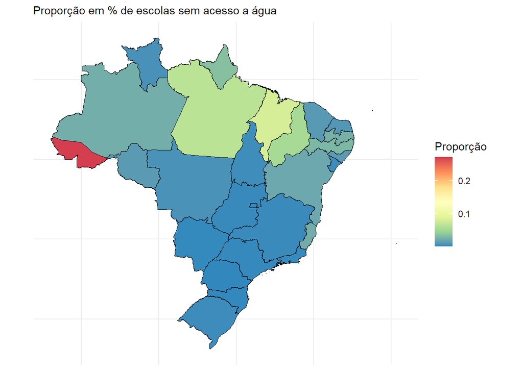

```r
par(mfrow=c(2,2))
states %>%
  filter(coluna == 'in_agua_inexistente') %>%
  mutate(prop_preenchida_sem_agua = 1 - (zeros/(zeros+uns))) %>%
  ggplot() +
    geom_sf(aes(fill=prop_preenchida_sem_agua), color= '#000000', size=.15) +
      labs(subtitle="Proporção em % de escolas sem acesso a água", size=8) +
      scale_fill_distiller(palette = "Spectral", name="Proporção") +
      theme_minimal() +
      no_axis
```

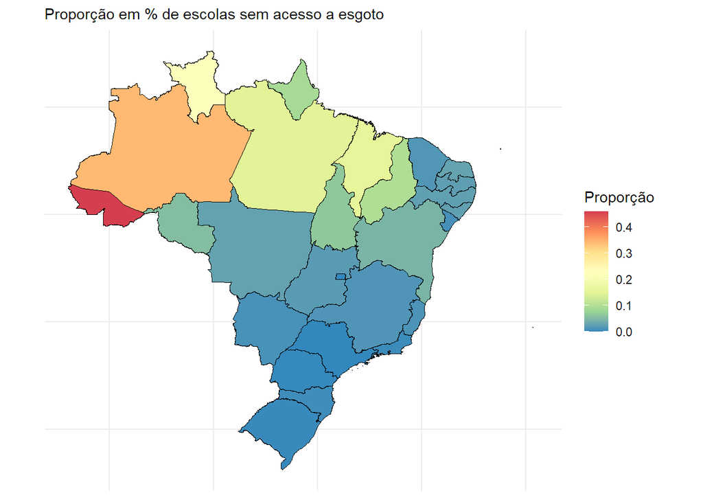

```r
states %>%
  filter(coluna == 'in_esgoto_inexistente') %>%
  mutate(prop_preenchida_sem_agua = 1 - (zeros/(zeros+uns))) %>%
  ggplot() +
    geom_sf(aes(fill=prop_preenchida_sem_agua), color= '#000000', size=.15) +
      labs(subtitle="Proporção em % de escolas sem acesso a esgoto", size=8) +
      scale_fill_distiller(palette = "Spectral", name="Proporção") +
      theme_minimal() +
      no_axis
```

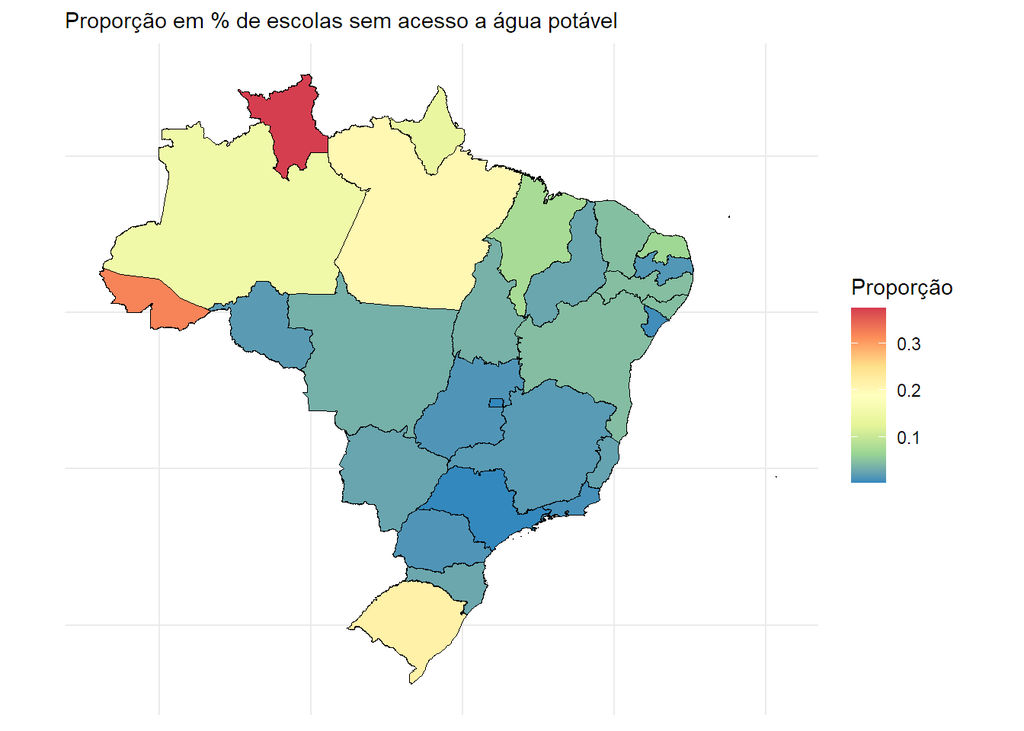

```r
states %>%
  filter(coluna == 'in_agua_potavel') %>%
  mutate(prop_preenchida_sem_agua = zeros/(zeros+uns)) %>%
  ggplot() +
    geom_sf(aes(fill=prop_preenchida_sem_agua), color= '#000000', size=.15) +
      labs(subtitle="Proporção em % de escolas sem acesso a água potável", size=8) +
      scale_fill_distiller(palette = "Spectral", name="Proporção") +
      theme_minimal() +
      no_axis
```

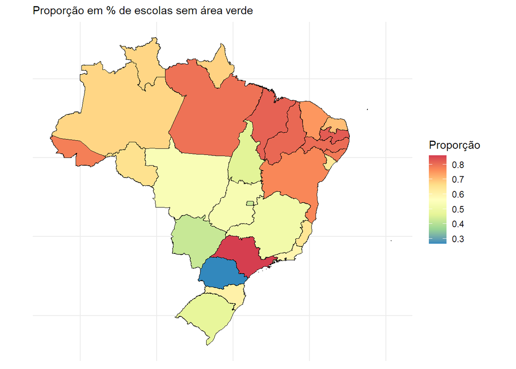

```r
states %>%
  filter(coluna == 'in_area_verde') %>%
  mutate(prop_preenchida_sem_agua = zeros/(zeros+uns)) %>%
  ggplot() +
    geom_sf(aes(fill=prop_preenchida_sem_agua), color= '#000000', size=.15) +
      labs(subtitle="Proporção em % de escolas sem área verde", size=8) +
      scale_fill_distiller(palette = "Spectral", name="Proporção") +
      theme_minimal() +
      no_axis
```

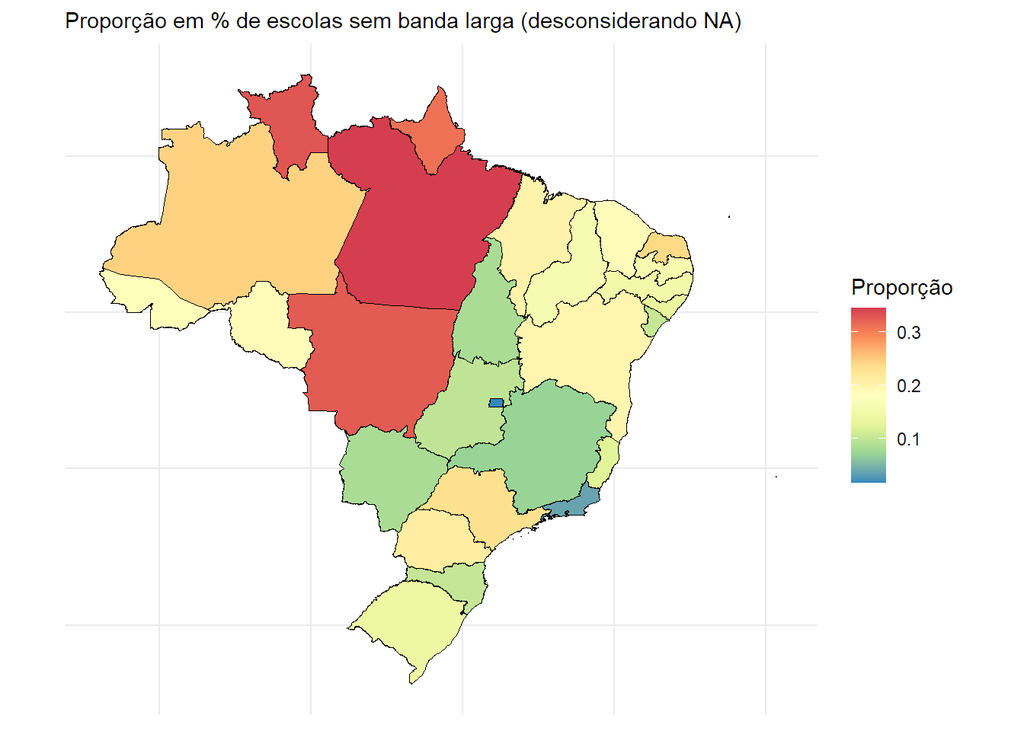

```r
states %>%
  filter(coluna == 'in_banda_larga') %>%
  mutate(prop_preenchida_sem_agua = zeros/(zeros+uns)) %>%
  ggplot() +
    geom_sf(aes(fill=prop_preenchida_sem_agua), color= '#000000', size=.15) +
      labs(subtitle="Proporção em % de escolas sem banda larga (desconsiderando NA)", size=8) +
      scale_fill_distiller(palette = "Spectral", name="Proporção") +
      theme_minimal() +
      no_axis
```

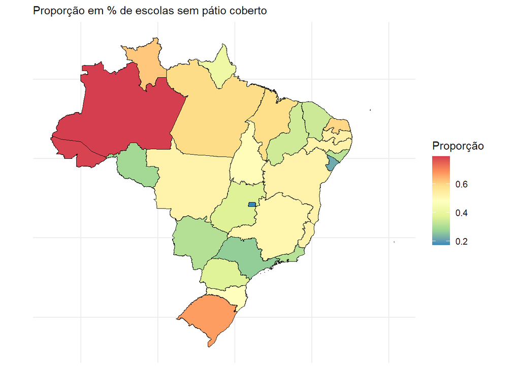

```r
states %>%
  filter(coluna == 'in_patio_coberto' | coluna == 'in_patio_coberto') %>%
  group_by(co_uf) %>%
  summarise(soma_zeros = sum(zeros),
            soma_uns = sum(uns)) %>%
  mutate(prop_preenchida_sem_agua = soma_zeros/(soma_zeros+soma_uns)) %>%
  ggplot() +
    geom_sf(aes(fill=prop_preenchida_sem_agua), color= '#000000', size=.15) +
      labs(subtitle="Proporção em % de escolas sem pátio coberto", size=8) +
      scale_fill_distiller(palette = "Spectral", name="Proporção") +
      theme_minimal() +
      no_axis
```

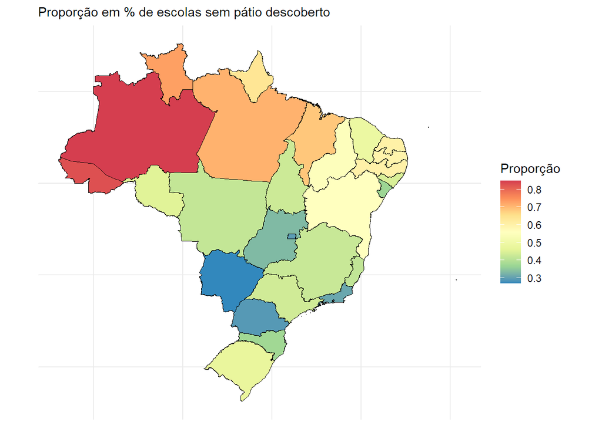

```r
states %>%
  filter(coluna == 'in_patio_descoberto' | coluna == 'in_patio_coberto') %>%
  group_by(co_uf) %>%
  summarise(soma_zeros = sum(zeros),
            soma_uns = sum(uns)) %>%
  mutate(prop_preenchida_sem_agua = soma_zeros/(soma_zeros+soma_uns)) %>%
  ggplot() +
    geom_sf(aes(fill=prop_preenchida_sem_agua), color= '#000000', size=.15) +
      labs(subtitle="Proporção em % de escolas sem pátio descoberto", size=8) +
      scale_fill_distiller(palette = "Spectral", name="Proporção") +
      theme_minimal() +
      no_axis
```

```r
save(sumario, file = '../apps/dados/sumario.rdata')
save(sumario2, file = '../apps/dados/sumario.rdata2')
save(sumario3, file = '../apps/dados/sumario.rdata3')
save(states, file = '../apps/dados/states.RData')
```

A tabela completa com os valores por estados pode ser explorada no endereço: https://jcoelho.shinyapps.io/tabela_estados/

Antes de prosseguir, é importante verificar o quão realistas as informações prestadas são. Foram identificados alguns casos que os dados do censo não condizem com a estrutura da instituição.

Por exemplo, o Instituto de Educação de Minas Gerais (cód.: 31001996) diz não possuir pátio coberto ou descoberto bem como não possuir auditório. Porém, sabe-se que o edifício possui pátios, como é possível inclusive observar das imagens:

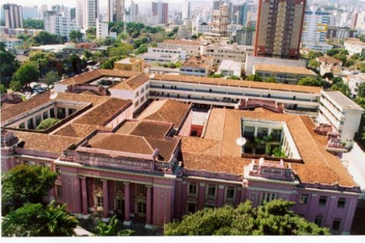

Foto aérea

bem como um auditório:

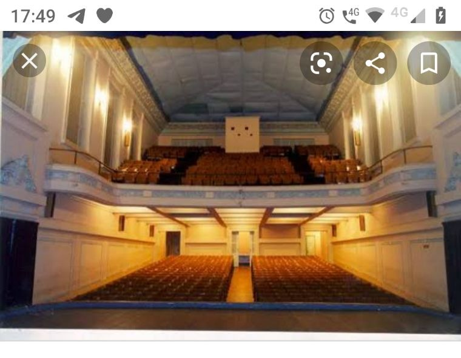

Foto auditório

Por fim, houve o caso também da escola EE Angelo Correia Viana (cód.: 31317357), que informava possuir apenas uma sala utilizada. Ao ligar para a escola no entanto, a diretora informou que o número de salas utilizadas era 12.

No caso do Rio, foi possível notar que uma escola particular que oferece ensino fundamental ao médio está cadastrada como duas instituições diferentes. Como consequência, o número de salas informadas, mesmo somando, está consideravelmente abaixo do total existente na instituição.

É relevante, portanto, entender que as informações prestadas podem não ser um retrato 100% fiel da situação das escolas.

Feitas essas considerações, passamos para a análise dos dados obtidos:

# III. Análise por estado

Não surpreendentemente, há uma grande disparidade regional no acesso a infraestrutura, com estados do norte e nordeste liderando na falta de água e esgoto. O Rio Grande do Sul se destaca por ser o único estado fora dessas duas regiões entre os 10 estados com maior proporção de escolas sem acesso à água potável. Com 22% de escolas nessa situação, o estado gaúcho é o terceiro pior colocado no Brasil. Se forem consideradas apenas as escolas públicas, esse valor sobe para 29%. Mais alarmante, no entanto, é o estado de Roraima, com quase 40% das escolas sem acesso a água potável.

Ainda assim, ambos estados ao menos possuem acesso à água, o que pode ser fundamental em um contexto de pandemia para questões de higiene. No estado do Acre, porém, 417 escolas (27% do total e 28% das escolas públicas) afirmaram ao censo que não possuem acesso à nenhuma fonte de água. Esse número está consideravelmente acima do segundo estado com a maior proporção de escolas sem água (Maranhão, com 8%).

Há, no entanto, um fato curioso. Algumas escolas estão com “água potavel” marcado como “1” e “in_agua_inexistente” também marcado como “1”, ou seja, a escola informa não possuir acesso a nenhuma fonte de água, mas que possui água potável.

A escola NORBERTO ASSUNCAO CAVALCANTE (cód.: 12001104), no catálogo de escolas do INEP consta como “Abastecimento de água” preenchido por “Cacimba/Cisterna/Poço” bem como “Água consumida pelos alunos” preenchido por “Potável”. Mais especificamente, 2147 escolas nessa situação. Só no Acre, 127 das 417 escolas sem acesso a água alegam ter água potável.

Não só isso, a [página](http://idebescola.inep.gov.br/ideb/escola/dadosEscola/12001104) de indicadores das Escolas do INEP diz que o abastecimento da escola é feito por “Cacimba/Cisterna/Poço”, mesmo com os dados do censo indicando que não há abastecimento em nenhuma forma, nem mesmo os citados:

```r
escolas %>%
  filter(co_entidade == '12001104') %>%
  knitr::kable("html") %>%
  kable_styling() %>%
  scroll_box(width = "100%", height = "200px")
```

| nu_ano_censo | co_entidade | no_entidade | co_orgao_regional | tp_situacao_funcionamento | dt_ano_letivo_inicio | dt_ano_letivo_termino | co_regiao | co_mesorregiao | co_microrregiao | co_uf | co_municipio | co_distrito | tp_dependencia | tp_localizacao | tp_localizacao_diferenciada | in_vinculo_secretaria_educacao | in_vinculo_seguranca_publica | in_vinculo_secretaria_saude | in_vinculo_outro_orgao | tp_categoria_escola_privada | in_conveniada_pp | tp_convenio_poder_publico | in_mant_escola_privada_emp | in_mant_escola_privada_ong | in_mant_escola_privada_oscip | in_mant_escola_priv_ong_oscip | in_mant_escola_privada_sind | in_mant_escola_privada_sist_s | in_mant_escola_privada_s_fins | … |
| --- | --- | --- | --- | --- | --- | --- | --- | --- | --- | --- | --- | --- | --- | --- | --- | --- | --- | --- | --- | --- | --- | --- | --- | --- | --- | --- | --- | --- | --- | --- |
| 2020 | 12001104 | ESC NORBERTO ASSUNCAO CAVALCANTE |  | 1 | 17/02/2020 | 22/12/2020 | 1 | 1201 | 12001 | 12 | 1200203 | 120020305 | 2 | 2 | 0 | 1 | 0 | 0 | 0 | NA | NA | NA | NA | NA | NA | NA | NA | NA | NA | … |

É uma possibilidade que os valores preenchidos, principalmente no Acre, estejam incorretos, ao menos em parte. Esse ponto deve ser considerado para análises macro usando os dados.

# V. Dados apenas públicas

```r
sumario_pub <- fun_sumar(escolas_pub)
```

```r
sumario_pub %>%
  knitr::kable("html") %>%
  kable_styling() %>%
  scroll_box(width = "100%", height = "500px")
```

| coluna | NAs | prop_na | zeros | prop_zero | uns | prop_uns |
| --- | --- | --- | --- | --- | --- | --- |
| in_agua_potavel | 0 | 0.00 | 9494 | 0.07 | 126929 | 0.93 |
| in_agua_inexistente | 0 | 0.00 | 133027 | 0.98 | 3396 | 0.02 |
| in_esgoto_inexistente | 0 | 0.00 | 127966 | 0.94 | 8457 | 0.06 |
| in_area_verde | 0 | 0.00 | 93697 | 0.69 | 42726 | 0.31 |
| in_banheiro | 0 | 0.00 | 5829 | 0.04 | 130594 | 0.96 |
| in_banheiro_funcionarios | 0 | 0.00 | 71342 | 0.52 | 65081 | 0.48 |
| in_patio_coberto | 0 | 0.00 | 68598 | 0.50 | 67825 | 0.50 |
| in_patio_descoberto | 0 | 0.00 | 77776 | 0.57 | 58647 | 0.43 |
| in_internet_administrativo | 0 | 0.00 | 38172 | 0.28 | 98251 | 0.72 |
| in_banda_larga | 34834 | 0.26 | 19021 | 0.14 | 82568 | 0.61 |
| qt_prof_saude | 0 | 0.00 | 134810 | 0.99 | 718 | 0.01 |

# V. Diferenças públicas x privadas

Há 4 opções para a coluna TP_DEPENDENCIA: 1 - Federal 2 - Estadual 3 - Municipal 4 - Privada

Vamos criar uma coluna com os equivalentes para facilitar a leitura:

```r
escolas2 <- escolas %>%
  mutate(Tipo = case_when(tp_dependencia == 1 ~ 'Federal', tp_dependencia == 2 ~ 'Estadual', tp_dependencia == 3 ~ 'Municipal', tp_dependencia == 4 ~ 'Privada' ))
```

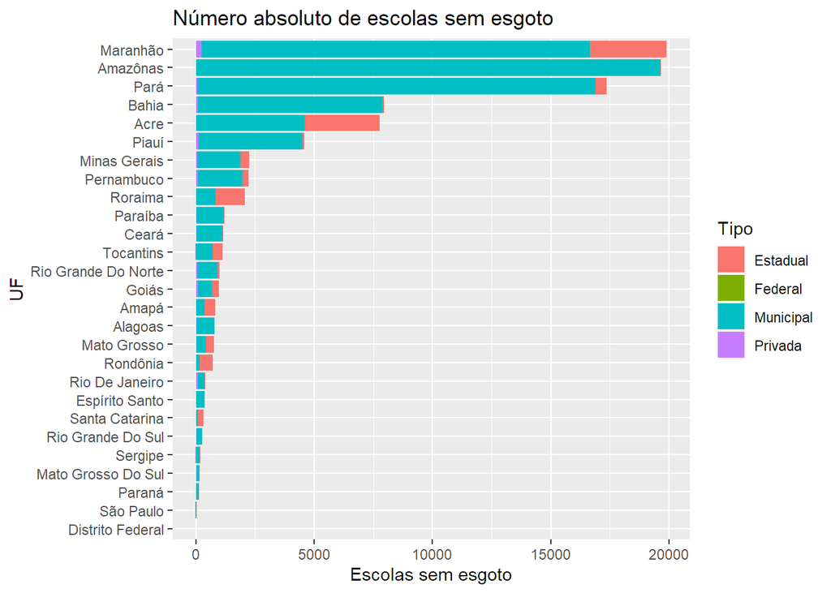

```r
escolas2 %>%
group_by(co_uf) %>%
  left_join(states, by = c('co_uf' = 'code_state')) %>%
mutate(total_de_escolas = n()) %>%
group_by(name_state, Tipo) %>%
summarise(n_escolas_sem_esgoto = sum(as.numeric(in_esgoto_inexistente)), total_de_escolas = total_de_escolas) %>%
unique() %>%
ggplot(aes(fill=Tipo, y=n_escolas_sem_esgoto, x=reorder(name_state, n_escolas_sem_esgoto))) +
geom_bar(position="stack", stat="identity") +
coord_flip() +
xlab('UF') +
ylab('Escolas sem esgoto') +
  ggtitle('Número absoluto de escolas sem esgoto')
```

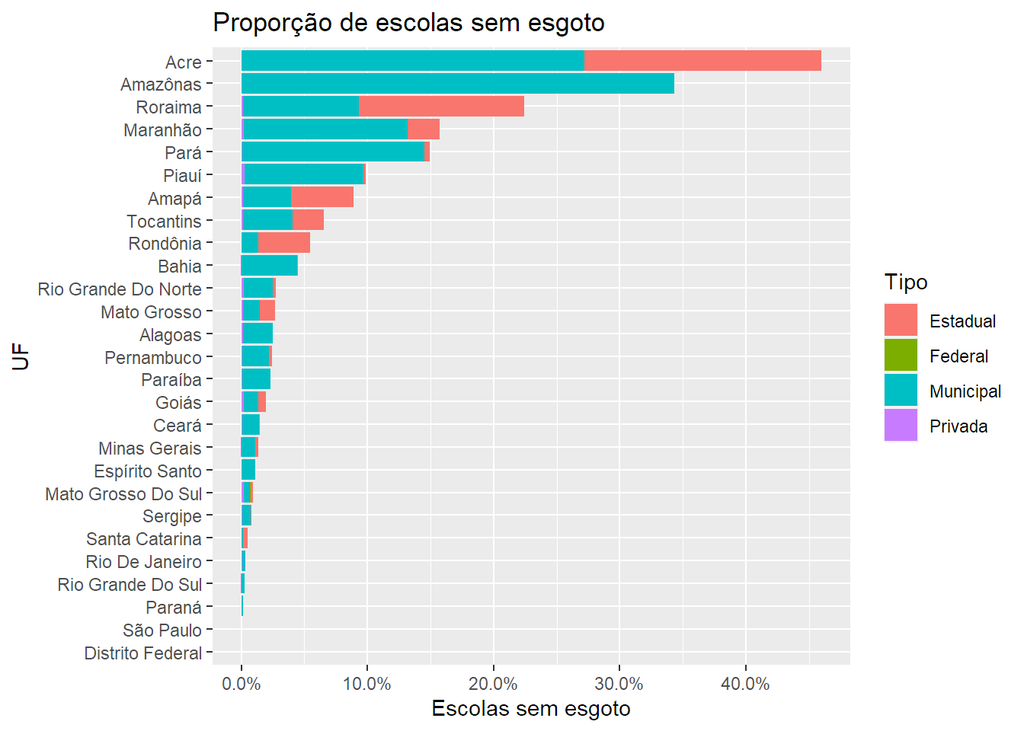

```r
escolas2 %>%
group_by(co_uf) %>%
  left_join(states, by = c('co_uf' = 'code_state')) %>%
mutate(total_de_escolas = n()) %>%
group_by(name_state, Tipo) %>%
summarise(n_escolas_sem_esgoto = sum(as.numeric(in_esgoto_inexistente)), total_de_escolas = total_de_escolas) %>%
mutate(prop_sem_esgoto = n_escolas_sem_esgoto/total_de_escolas) %>%
unique() %>%
  ggplot(aes(fill=Tipo, y=prop_sem_esgoto, x=reorder(name_state, prop_sem_esgoto))) +
geom_bar(position="stack", stat="identity") +
coord_flip() +
xlab('UF') +
ylab('Escolas sem esgoto') +
scale_y_continuous(labels = scales::percent) +
  ggtitle('Proporção de escolas sem esgoto')
```

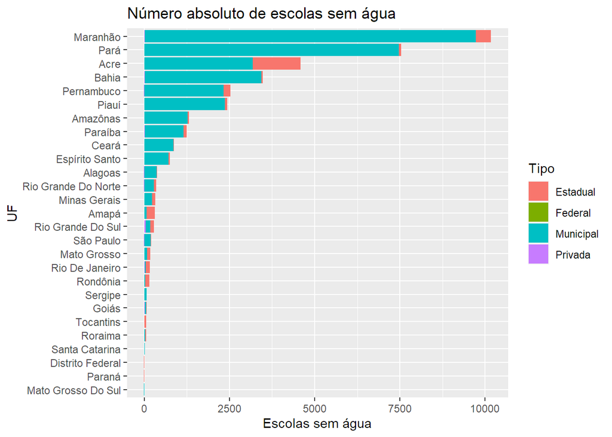

```r
escolas2 %>%
group_by(co_uf) %>%
  left_join(states, by = c('co_uf' = 'code_state')) %>%
mutate(total_de_escolas = n()) %>%
group_by(name_state, Tipo) %>%
summarise(n_escolas_sem_agua = sum(as.numeric(in_agua_inexistente)), total_de_escolas = total_de_escolas) %>%
unique() %>%
ggplot(aes(fill=Tipo, y=n_escolas_sem_agua, x=reorder(name_state, n_escolas_sem_agua))) +
geom_bar(position="stack", stat="identity") +
coord_flip() +
xlab('UF') +
ylab('Escolas sem água') +
  ggtitle('Número absoluto de escolas sem água')
```

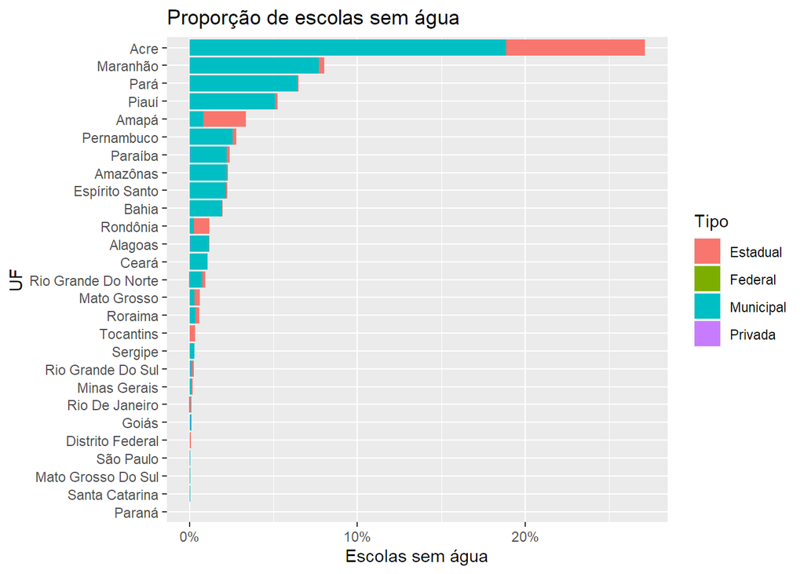

```r
escolas2 %>%
group_by(co_uf) %>%
  left_join(states, by = c('co_uf' = 'code_state')) %>%
mutate(total_de_escolas = n()) %>%
group_by(name_state, Tipo) %>%
summarise(n_escolas_sem_agua = sum(as.numeric(in_agua_inexistente)), total_de_escolas = total_de_escolas) %>%
mutate(prop_sem_esgoto = n_escolas_sem_agua/total_de_escolas) %>%
unique() %>%
  ggplot(aes(fill=Tipo, y=prop_sem_esgoto, x=reorder(name_state, prop_sem_esgoto))) +
geom_bar(position="stack", stat="identity") +
coord_flip() +
xlab('UF') +
ylab('Escolas sem água') +
scale_y_continuous(labels = scales::percent) +
  ggtitle('Proporção de escolas sem água')
```

Tabelas com as informações acima

## Número absoluto de escolas sem esgoto

```r
escolas2 %>%
group_by(co_uf) %>%
  left_join(states, by = c('co_uf' = 'code_state')) %>%
mutate(total_de_escolas = n()) %>%
group_by(name_state, Tipo) %>%
summarise(n_escolas_sem_esgoto = sum(as.numeric(in_esgoto_inexistente)), total_de_escolas = total_de_escolas) %>%
unique()
```

| name_state | Tipo | n_escolas_sem_esgoto | total_de_escolas |
| --- | --- | --- | --- |
| Acre | Estadual | 3179 | 16918 |
| Acre | Federal | 0 | 16918 |
| Acre | Municipal | 4598 | 16918 |
| Acre | Privada | 0 | 16918 |
| Alagoas | Estadual | 0 | 31460 |
| Alagoas | Federal | 0 | 31460 |
| Alagoas | Municipal | 737 | 31460 |
| Alagoas | Privada | 44 | 31460 |
| Amapá | Estadual | 451 | 9130 |
| Amapá | Federal | 0 | 9130 |

[output cut: 97 more lines]

## Proporção de escolas sem esgoto

```r
escolas2 %>%
group_by(co_uf) %>%
  left_join(states, by = c('co_uf' = 'code_state')) %>%
mutate(total_de_escolas = n()) %>%
group_by(name_state, Tipo) %>%
summarise(n_escolas_sem_esgoto = sum(as.numeric(in_esgoto_inexistente)), total_de_escolas = total_de_escolas) %>%
mutate(prop_sem_esgoto = n_escolas_sem_esgoto/total_de_escolas) %>%
unique()
```

| name_state | Tipo | n_escolas_sem_esgoto | total_de_escolas | prop_sem_esgoto |
| --- | --- | --- | --- | --- |
| Acre | Estadual | 3179 | 16918 | 1.879064e-01 |
| Acre | Federal | 0 | 16918 | 0.000000e+00 |
| Acre | Municipal | 4598 | 16918 | 2.717815e-01 |
| Acre | Privada | 0 | 16918 | 0.000000e+00 |
| Alagoas | Estadual | 0 | 31460 | 0.000000e+00 |
| Alagoas | Federal | 0 | 31460 | 0.000000e+00 |
| Alagoas | Municipal | 737 | 31460 | 2.342657e-02 |
| Alagoas | Privada | 44 | 31460 | 1.398601e-03 |
| Amapá | Estadual | 451 | 9130 | 4.939759e-02 |
| Amapá | Federal | 0 | 9130 | 0.000000e+00 |

[output cut: 97 more lines]

## Número absoluto de escolas sem água

```r
escolas2 %>%
group_by(co_uf) %>%
  left_join(states, by = c('co_uf' = 'code_state')) %>%
mutate(total_de_escolas = n()) %>%
group_by(name_state, Tipo) %>%
summarise(n_escolas_sem_agua = sum(as.numeric(in_agua_inexistente)), total_de_escolas = total_de_escolas) %>%
unique()
```

| name_state | Tipo | n_escolas_sem_agua | total_de_escolas |
| --- | --- | --- | --- |
| Acre | Estadual | 1397 | 16918 |
| Acre | Federal | 0 | 16918 |
| Acre | Municipal | 3190 | 16918 |
| Acre | Privada | 0 | 16918 |
| Alagoas | Estadual | 11 | 31460 |
| Alagoas | Federal | 0 | 31460 |
| Alagoas | Municipal | 352 | 31460 |
| Alagoas | Privada | 11 | 31460 |
| Amapá | Estadual | 231 | 9130 |
| Amapá | Federal | 0 | 9130 |

[output cut: 97 more lines]

## Proporção de escolas sem água

```r
escolas2 %>%
group_by(co_uf) %>%
  left_join(states, by = c('co_uf' = 'code_state')) %>%
mutate(total_de_escolas = n()) %>%
group_by(name_state, Tipo) %>%
summarise(n_escolas_sem_agua = sum(as.numeric(in_agua_inexistente)), total_de_escolas = total_de_escolas) %>%
mutate(prop_sem_esgoto = n_escolas_sem_agua/total_de_escolas) %>%
unique()
```

| name_state | Tipo | n_escolas_sem_agua | total_de_escolas | prop_sem_esgoto |
| --- | --- | --- | --- | --- |
| Acre | Estadual | 1397 | 16918 | 8.257477e-02 |
| Acre | Federal | 0 | 16918 | 0.000000e+00 |
| Acre | Municipal | 3190 | 16918 | 1.885566e-01 |
| Acre | Privada | 0 | 16918 | 0.000000e+00 |
| Alagoas | Estadual | 11 | 31460 | 3.496503e-04 |
| Alagoas | Federal | 0 | 31460 | 0.000000e+00 |
| Alagoas | Municipal | 352 | 31460 | 1.118881e-02 |
| Alagoas | Privada | 11 | 31460 | 3.496503e-04 |
| Amapá | Estadual | 231 | 9130 | 2.530120e-02 |
| Amapá | Federal | 0 | 9130 | 0.000000e+00 |

[output cut: 97 more lines]